# Assessment of In Silico Tools for Variant Effect Prediction in Haemoglobinopathies

# Assessment of In Silico Tools for Variant Effect Prediction in Haemoglobinopathies

## Setup

```r
library(readxl)
library(ggplot2)
library(pheatmap)
library(writexl)
library(janitor)
library(readr)
library(dplyr)
library(tidyr)
library(tidyverse)
```

```r
output_directory <- "results"

results_directory <- output_directory

tables_directory <- file.path(
  output_directory,
  "tables"
)

figures_directory <- file.path(
  output_directory,
  "figures"
)

processed_data_directory <- file.path(
  "data",
  "processed"
)

dir.create(
  output_directory,
  recursive = TRUE,
  showWarnings = FALSE
)

dir.create(
  tables_directory,
  recursive = TRUE,
  showWarnings = FALSE
)

dir.create(
  figures_directory,
  recursive = TRUE,
  showWarnings = FALSE
)

dir.create(
  processed_data_directory,
  recursive = TRUE,
  showWarnings = FALSE
)

cat("Output directory:", output_directory, "\n")
```

```
## Output directory: results
```

```r
cat("Tables directory:", tables_directory, "\n")
```

```
## Tables directory: results/tables
```

```r
cat("Figures directory:", figures_directory, "\n")
```

```
## Figures directory: results/figures
```

```r
cat("Processed data directory:", processed_data_directory, "\n")
```

```
## Processed data directory: data/processed
```

````r
rmd_lines <- readLines("WORKING NOTEBOOK.Rmd", warn = FALSE)

# 1. Find all R chunk labels
chunk_lines <- grep("^```\\{r", rmd_lines)
chunk_text <- rmd_lines[chunk_lines]

chunk_labels <- sub("^```\\{r\\s*", "", chunk_text)
chunk_labels <- sub(",.*$", "", chunk_labels)
chunk_labels <- sub("\\}.*$", "", chunk_labels)
chunk_labels <- trimws(chunk_labels)

chunk_audit <- data.frame(
  line = chunk_lines,
  chunk_label = chunk_labels
)

# 2. Find duplicate chunk labels
duplicate_chunks <- chunk_audit[
  duplicated(chunk_audit$chunk_label) |
    duplicated(chunk_audit$chunk_label, fromLast = TRUE),
]

duplicate_chunks

# 3. Find plain ```r fences
plain_r_fences <- grep("^```r\\s*$", rmd_lines)

plain_r_fence_audit <- data.frame(
  line = plain_r_fences,
  text = rmd_lines[plain_r_fences]
)

plain_r_fence_audit

# 4. Find all output_directory definitions
output_directory_lines <- grep("output_directory\\s*<-", rmd_lines)

output_directory_audit <- data.frame(
  line = output_directory_lines,
  text = rmd_lines[output_directory_lines]
)

output_directory_audit

# 5. Find performance-summary object names
performance_lines <- grep(
  "tool_performance_summary|binary_tool_performance_summary",
  rmd_lines
)

performance_audit <- data.frame(
  line = performance_lines,
  text = rmd_lines[performance_lines]
)

performance_audit

# 6. Find tool-category map definitions
category_map_lines <- grep(
  "tool_category_map\\s*<-|binary_tool_category_map\\s*<-",
  rmd_lines
)

category_map_audit <- data.frame(
  line = category_map_lines,
  text = rmd_lines[category_map_lines]
)

category_map_audit
````

## Load dataset

```r
DATASET_FOR_PROJECT <- read_excel(
  "DATASET FOR PROJECT.xlsx",
  sheet = "Input-Full dataset"
)
```

## Dataset overview

```r
# Number of rows and columns
dim(DATASET_FOR_PROJECT)
```

```
## [1] 1627   45
```

```r
# View column names
names(DATASET_FOR_PROJECT)
```

```
##  [1] "ithaID"                            "changes"
##  [3] "Vep_input"                         "GRCh38 Vep_input"
##  [5] "HGVS"                              "HGVS_transcript"
##  [7] "HGVS_protein"                      "Initial_observed_pathogenicity"
##  [9] "Observed_pathogenicity"            "Effect_function"
## [11] "Location"                          "Consequence"
## [13] "SIFT_score"                        "integrated_fitCons_score"
## [15] "MutationTaster_score"              "LRT_score"
## [17] "PolyPhen_score"                    "SpliceAI_DS"
## [19] "ClinPred_score"                    "DANN_score"
## [21] "LIST-S2_score_seperated"           "MetaSVM_score"
## [23] "MutPred_score"                     "REVEL_score"
## [25] "VEST4_score_seperated"             "fathmm-MKL_coding_score"
## [27] "ada_score"                         "rf_score"
## [29] "Condel_score"                      "MetaLR_score"
## [31] "GERP++_RS"                         "Eigen-PC-phred_coding"
## [33] "BayesDel_addAF_score"              "FATHMM_score_seperated"
## [35] "MutationAssessor_standalone_score" "PROVEAN_score_seperated"
## [37] "CADD_PHRED"                        "phyloP100way_vertebrate"
## [39] "phyloP30way_mammalian"             "phastCons30way_mammalian"
## [41] "phastCons17way_primate"            "SiPhy_29way_logOdds"
## [43] "Eigen-phred_coding"                "MaxEntScan_diff"
## [45] "MaxEntScan_score"
```

```r
# Summary of dataset
summary(DATASET_FOR_PROJECT)
```

```
##      ithaID       changes         Vep_input         GRCh38 Vep_input
##  Min.   :   1.0   Mode:logical   Length:1627        Length:1627
##  1st Qu.: 529.5   TRUE:1         Class :character   Class :character
##  Median :1060.0   NA's:1626      Mode  :character   Mode  :character
##  Mean   :1433.7
##  3rd Qu.:2392.0
##  Max.   :3785.0
##
##      HGVS           HGVS_transcript    HGVS_protein
##  Length:1627        Length:1627        Length:1627
##  Class :character   Class :character   Class :character
##  Mode  :character   Mode  :character   Mode  :character
##
##
##
##
##  Initial_observed_pathogenicity Observed_pathogenicity Effect_function
##  Length:1627                    Length:1627            Length:1627
##  Class :character               Class :character       Class :character
##  Mode  :character               Mode  :character       Mode  :character
##
##
##
##
##    Location         Consequence          SIFT_score
##  Length:1627        Length:1627        Min.   :0.0000
##  Class :character   Class :character   1st Qu.:0.0000
##  Mode  :character   Mode  :character   Median :0.0100
##                                        Mean   :0.0834
##                                        3rd Qu.:0.0600
##                                        Max.   :1.0000
##                                        NA's   :620
##  integrated_fitCons_score MutationTaster_score   LRT_score
##  Min.   :0.0610           Min.   :0.5015       Min.   :0.0000
##  1st Qu.:0.4871           1st Qu.:0.9979       1st Qu.:0.0000
##  Median :0.4974           Median :1.0000       Median :0.0001
##  Mean   :0.5353           Mean   :0.9767       Mean   :0.0666
##  3rd Qu.:0.5977           3rd Qu.:1.0000       3rd Qu.:0.0256
##  Max.   :0.6766           Max.   :1.0000       Max.   :0.9580
##  NA's   :571              NA's   :571          NA's   :1188
```

[output cut: 57 more lines]

```
##  Min.   :0.0000         Min.   : 0.1951     Min.   : 0.0019    Min.   :-2.201
##  1st Qu.:0.2040         1st Qu.: 7.8209     1st Qu.: 1.4877    1st Qu.: 1.403
##  Median :0.7460         Median :10.8925     Median : 3.0869    Median : 4.000
##  Mean   :0.6066         Mean   :10.6476     Mean   : 4.2027    Mean   : 4.683
##  3rd Qu.:0.9562         3rd Qu.:14.1449     3rd Qu.: 5.9029    3rd Qu.: 8.182
##  Max.   :1.0000         Max.   :21.0507     Max.   :17.6136    Max.   :14.436
##  NA's   :571            NA's   :571         NA's   :571        NA's   :1533
##  MaxEntScan_score
##  Min.   :-23.79
##  1st Qu.: 14.28
##  Median : 47.56
##  Mean   : 49.41
##  3rd Qu.: 84.87
##  Max.   :127.57
##  NA's   :1533
```

```r
# Total rows and columns
total_rows <- nrow(DATASET_FOR_PROJECT)
total_columns <- ncol(DATASET_FOR_PROJECT)

dataset_overview <- data.frame(
  total_rows = total_rows,
  total_columns = total_columns
)

dataset_overview
```

```
##   total_rows total_columns
## 1       1627            45
```

## Unique variants

```r
unique_variants_summary <- data.frame(
  total_rows = nrow(DATASET_FOR_PROJECT),
  unique_variants = length(unique(DATASET_FOR_PROJECT$vep_input)),
  unique_HGVS = length(unique(DATASET_FOR_PROJECT$HGVS))
)
unique_variants_summary
```

```
##   total_rows unique_variants unique_HGVS
## 1       1627               0        1627
```

# Descriptive Analysis

## Pathogenicity distribution

This analysis summarises the nuber and percentage of variants in each observed pathogenicity category, helping to determine if the dataset is balanced across the various pathogenicity categories

```r
pathogenicity_table <- table(DATASET_FOR_PROJECT$Observed_pathogenicity)

pathogenicity_summary <- data.frame(
  Observed_pathogenicity = names(pathogenicity_table),
  n = as.integer(pathogenicity_table)
)

pathogenicity_summary$percentage <- round(
  pathogenicity_summary$n / sum(pathogenicity_summary$n) * 100,
  1
)

pathogenicity_summary
```

```
##   Observed_pathogenicity   n percentage
## 1                   B/LB 194       11.9
## 2                   P/LP 832       51.1
## 3                    VUS 601       36.9
```

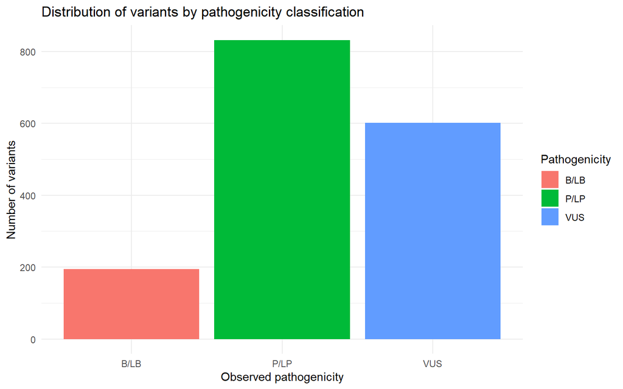

The results indicate that the dayaset contains a higher nuber of P/LP compared to the B/LB variants. it also showed that the dataset contained a large number of VUS which highlights the need for computational prediction tools in variant interpretation

## Variant effect distribution

This analysis examines the funtional consequences of variants in the dataset, showing how the the various different variant effect categories such as misssense,promoter,frameshift,spliceregion and UTR variants are ditributed across the observed pathogenicity classes

```r
effect_summary <- as.data.frame(
  table(
    DATASET_FOR_PROJECT$Effect_function,
    DATASET_FOR_PROJECT$Observed_pathogenicity
  )
)

colnames(effect_summary) <- c(
  "Effect_function",
  "Observed_pathogenicity",
  "n"
)

effect_summary <- effect_summary[effect_summary$n > 0, ]

effect_summary$percentage_within_effect <- ave(
  effect_summary$n,
  effect_summary$Effect_function,
  FUN = function(x) round(x / sum(x) * 100, 1)
)

effect_summary <- effect_summary[
  order(effect_summary$n, decreasing = TRUE),
]

effect_summary
```

```
##                                           Effect_function
## 75                                        Missense codons
## 44                                        Missense codons
## 38                                             Frameshift
## 13                                        Missense codons
## 39                                         Inframe indels
## 60                                            Stop gained
## 47                                               Promoter
## 31                                Synonymous substitution
## 51                                  Splice region variant
## 40                                       Initiation codon
## 50                                           Splice donor
## 49                                        Splice acceptor
## 54                 Splice region variant; Missense codons
## 85                 Splice region variant; Missense codons
```

[output cut: 97 more lines]

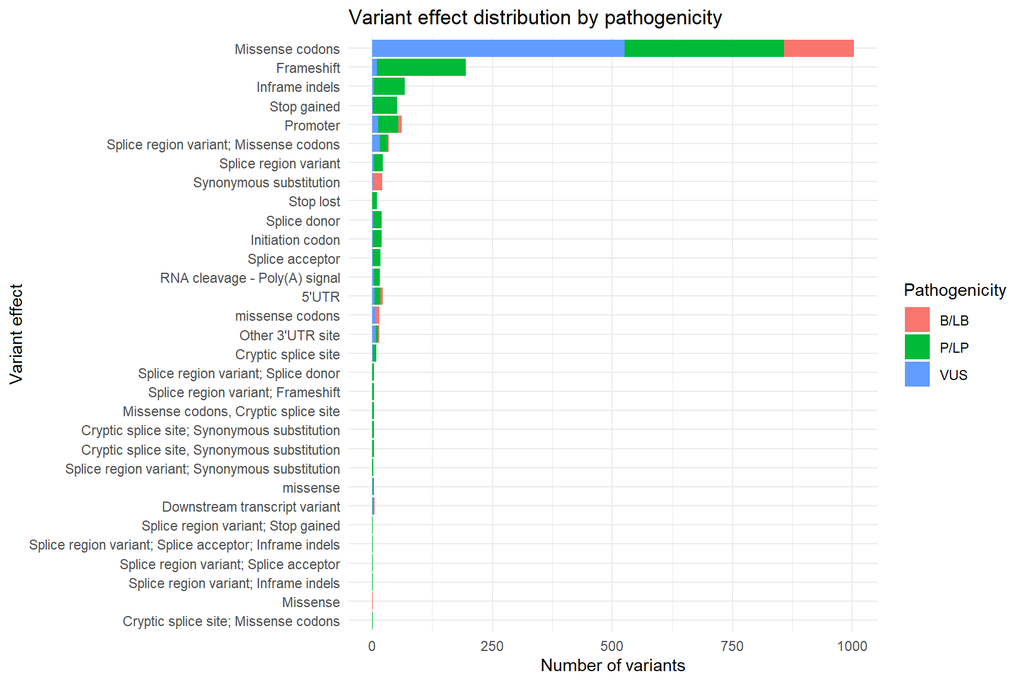

the distribution identified that missense variants were the most abundant in the dataset

## Missense versus non-missense variants

This focuses on the grouping of variants into missense and non missense categories in order to determine the quantity of the dataset relevant for in silico prediction

```r
DATASET_FOR_PROJECT$variant_group <- ifelse(
  grepl("missense", DATASET_FOR_PROJECT$Effect_function, ignore.case = TRUE),
  "Missense",
  "Non-missense"
)

variant_group_summary <- as.data.frame(
  table(
    DATASET_FOR_PROJECT$variant_group,
    DATASET_FOR_PROJECT$Observed_pathogenicity
  )
)

colnames(variant_group_summary) <- c(
  "variant_group",
  "Observed_pathogenicity",
  "n"
)

variant_group_summary <- variant_group_summary[variant_group_summary$n > 0, ]

variant_group_summary$percentage <- ave(
  variant_group_summary$n,
  variant_group_summary$variant_group,
  FUN = function(x) round(x / sum(x) * 100, 1)
)

variant_group_summary
```

```
##   variant_group Observed_pathogenicity   n percentage
## 1      Missense                   B/LB 156       14.7
## 2  Non-missense                   B/LB  38        6.7
## 3      Missense                   P/LP 355       33.5
## 4  Non-missense                   P/LP 477       84.1
## 5      Missense                    VUS 549       51.8
## 6  Non-missense                    VUS  52        9.2
```

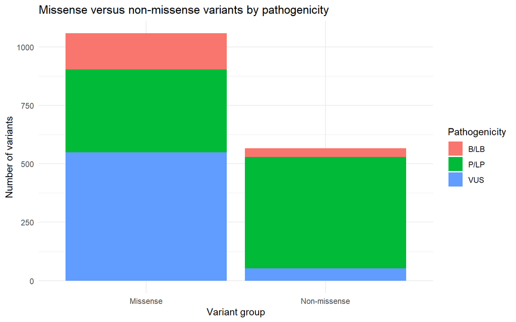

The results indicate that missense variants make up a majority of VUS supporting its relevance in tools evaluation

## VUS distribution

This analysis focuses only on variants classified as VUS to identify which variant effect categories contribute most to uncertainty in the dataset

```r
vus_data <- DATASET_FOR_PROJECT[
  DATASET_FOR_PROJECT$Observed_pathogenicity == "VUS",
]

vus_summary <- as.data.frame(
  table(
    vus_data$HGVS,
    vus_data$Effect_function
  )
)

colnames(vus_summary) <- c(
  "HGVS",
  "Effect_function",
  "n"
)

vus_summary <- vus_summary[vus_summary$n > 0, ]

vus_summary <- vus_summary[
  order(vus_summary$n, decreasing = TRUE),
]

vus_summary
```

```
##                                        HGVS
## 1                             HBA1:c.-15C>G
## 2                             HBA1:c.-16T>C
## 89                            HBA2:c.-15C>G
## 90                            HBA2:c.-27T>A
## 208                            HBB:c.-24C>G
## 1042                        HBB:c.316-70C>G
## 1421                          HBB:c.*261T>C
## 1827                         HBA1:c.189delG
## 1833                         HBA1:c.202delA
## 1871                         HBA1:c.404delC
## 1912  HBA2:c.142_161delGACCTGAGCCACGGCTCTGC
## 1919                          HBA2:c.163del
## 1974               HBA2:c.400_406delAGCACCG
## 1983                         HBA2:c.420delA
```

[output cut: 1189 more lines]

```r
vus_effect_summary <- aggregate(
  n ~ Effect_function,
  data = vus_summary,
  FUN = sum
)

vus_effect_summary <- vus_effect_summary[
  order(vus_effect_summary$n, decreasing = TRUE),
]

vus_effect_summary
```

```
##                           Effect_function   n
## 9                         Missense codons 526
## 16 Splice region variant; Missense codons  16
## 11                               Promoter  12
## 4                              Frameshift  10
## 10                       Other 3'UTR site   7
## 8                         missense codons   6
## 1                                   5'UTR   5
## 12          RNA cleavage - Poly(A) signal   4
## 5                          Inframe indels   3
## 15                  Splice region variant   3
## 14                           Splice donor   2
## 2                     Cryptic splice site   1
## 3           Downstream transcript variant   1
## 6                        Initiation codon   1
## 7                                missense   1
## 13                        Splice acceptor   1
## 17                            Stop gained   1
## 18                Synonymous substitution   1
```

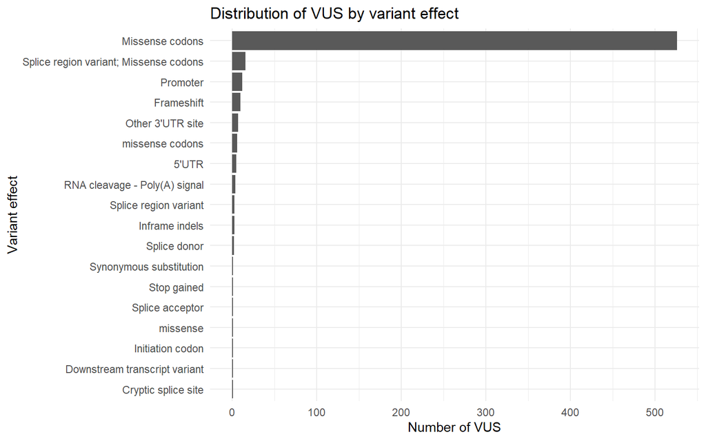

## Classified variants: P/LP versus B/LB

It excludes VUS,comparing only on varaints with clearer clinical classification inorder to assess the balance of classified variants.

```r
counts_table <- table(DATASET_FOR_PROJECT$Observed_pathogenicity)

counts_table <- counts_table[
  names(counts_table) %in% c("P/LP", "B/LB")
]

classified_counts <- data.frame(
  Observed_pathogenicity = names(counts_table),
  n = as.integer(counts_table)
)

classified_counts$percentage <- round(
  classified_counts$n / sum(classified_counts$n) * 100,
  1
)

classified_counts
```

```
##   Observed_pathogenicity   n percentage
## 1                   B/LB 194       18.9
## 2                   P/LP 832       81.1
```

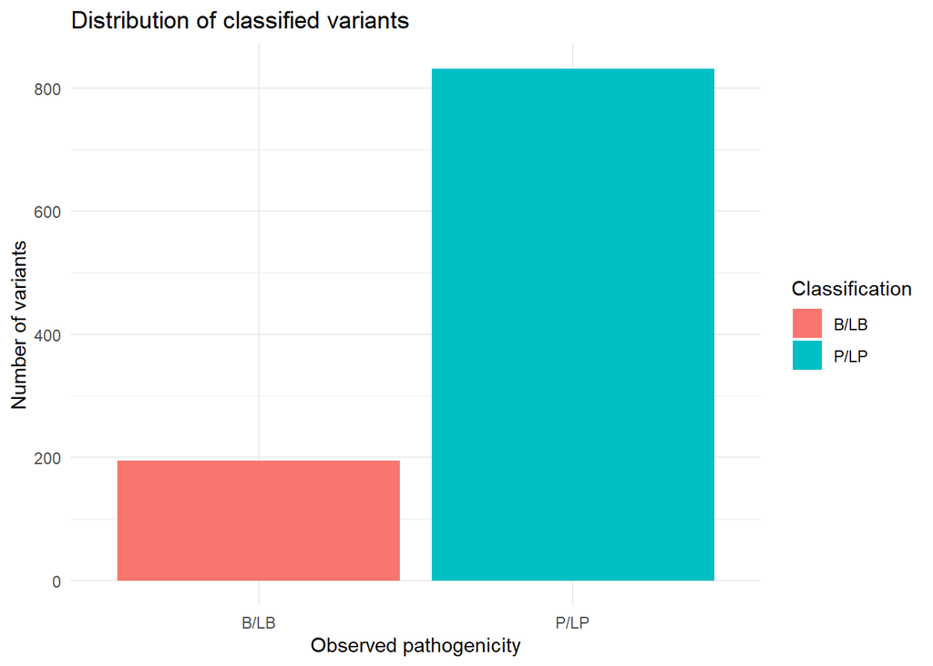

As P/LP was in greateR quantities than B/LB,it is necessary for this imbalance to be considered during later performance analysis as metrics such as accuracy may be affected when one class is larger than the other.

## Missingness analysis of prediction tools

It analyses how much prediction score data is available for each tool for fair comparison of the tools

```r
tool_cols <- c(
  "SIFT_score",
  "integrated_fitCons_score",
  "MutationTaster_score",
  "LRT_score",
  "PolyPhen_score",
  "SpliceAI_DS",
  "ClinPred_score",
  "DANN_score",
  "LIST-S2_score_seperated",
  "MetaSVM_score",
  "MutPred_score",
  "REVEL_score",
  "VEST4_score_seperated",
  "fathmm-MKL_coding_score",
  "ada_score",
  "rf_score",
  "Condel_score",
  "MetaLR_score",
  "GERP++_RS",
  "Eigen-PC-phred_coding",
  "BayesDel_addAF_score",
  "FATHMM_score_seperated",
  "MutationAssessor_standalone_score",
  "PROVEAN_score_seperated",
  "CADD_PHRED",
  "phyloP100way_vertebrate",
  "phyloP30way_mammalian",
  "phastCons30way_mammalian",
  "phastCons17way_primate",
  "SiPhy_29way_logOdds",
  "Eigen-phred_coding",
  "MaxEntScan_diff",
  "MaxEntScan_score"
)

tool_cols <- tool_cols[tool_cols %in% names(DATASET_FOR_PROJECT)]

tool_cols
```

```
##  [1] "SIFT_score"                        "integrated_fitCons_score"
##  [3] "MutationTaster_score"              "LRT_score"
##  [5] "PolyPhen_score"                    "SpliceAI_DS"
##  [7] "ClinPred_score"                    "DANN_score"
##  [9] "LIST-S2_score_seperated"           "MetaSVM_score"
## [11] "MutPred_score"                     "REVEL_score"
## [13] "VEST4_score_seperated"             "fathmm-MKL_coding_score"
## [15] "ada_score"                         "rf_score"
## [17] "Condel_score"                      "MetaLR_score"
## [19] "GERP++_RS"                         "Eigen-PC-phred_coding"
## [21] "BayesDel_addAF_score"              "FATHMM_score_seperated"
## [23] "MutationAssessor_standalone_score" "PROVEAN_score_seperated"
## [25] "CADD_PHRED"                        "phyloP100way_vertebrate"
## [27] "phyloP30way_mammalian"             "phastCons30way_mammalian"
## [29] "phastCons17way_primate"            "SiPhy_29way_logOdds"
## [31] "Eigen-phred_coding"                "MaxEntScan_diff"
## [33] "MaxEntScan_score"
```

```r
missing_counts <- sapply(
  DATASET_FOR_PROJECT[tool_cols],
  function(x) sum(is.na(x))
)

available_counts <- sapply(
  DATASET_FOR_PROJECT[tool_cols],
  function(x) sum(!is.na(x))
)

missingness_summary <- data.frame(
  tool = names(missing_counts),
  missing_n = as.integer(missing_counts),
  available_n = as.integer(available_counts),
  missing_percentage = round(missing_counts / nrow(DATASET_FOR_PROJECT) * 100, 1),
  available_percentage = round(available_counts / nrow(DATASET_FOR_PROJECT) * 100, 1)
)

missingness_summary <- missingness_summary[
  order(missingness_summary$missing_percentage, decreasing = TRUE),
]

missingness_summary
```

```
##                                                                tool missing_n
## ada_score                                                 ada_score      1534
## rf_score                                                   rf_score      1534
## MaxEntScan_diff                                     MaxEntScan_diff      1533
## MaxEntScan_score                                   MaxEntScan_score      1533
## LRT_score                                                 LRT_score      1188
## LIST-S2_score_seperated                     LIST-S2_score_seperated       846
## MutationAssessor_standalone_score MutationAssessor_standalone_score       817
## MutPred_score                                         MutPred_score       643
## ClinPred_score                                       ClinPred_score       621
## MetaSVM_score                                         MetaSVM_score       621
## REVEL_score                                             REVEL_score       621
## MetaLR_score                                           MetaLR_score       621
## FATHMM_score_seperated                       FATHMM_score_seperated       621
## PROVEAN_score_seperated                     PROVEAN_score_seperated       621
## SIFT_score                                               SIFT_score       620
## PolyPhen_score                                       PolyPhen_score       620
## Condel_score                                           Condel_score       620
## integrated_fitCons_score                   integrated_fitCons_score       571
## MutationTaster_score                           MutationTaster_score       571
## DANN_score                                               DANN_score       571
## VEST4_score_seperated                         VEST4_score_seperated       571
## fathmm-MKL_coding_score                     fathmm-MKL_coding_score       571
## GERP++_RS                                                 GERP++_RS       571
## Eigen-PC-phred_coding                         Eigen-PC-phred_coding       571
## BayesDel_addAF_score                           BayesDel_addAF_score       571
## phyloP100way_vertebrate                     phyloP100way_vertebrate       571
## phyloP30way_mammalian                         phyloP30way_mammalian       571
## phastCons30way_mammalian                   phastCons30way_mammalian       571
## phastCons17way_primate                       phastCons17way_primate       571
## SiPhy_29way_logOdds                             SiPhy_29way_logOdds       571
## Eigen-phred_coding                               Eigen-phred_coding       571
## SpliceAI_DS                                             SpliceAI_DS       445
## CADD_PHRED                                               CADD_PHRED       160
##                                   available_n missing_percentage
## ada_score                                  93               94.3
## rf_score                                   93               94.3
## MaxEntScan_diff                            94               94.2
## MaxEntScan_score                           94               94.2
## LRT_score                                 439               73.0
```

[output cut: 47 more lines]

```
## MutationTaster_score                              64.9
## DANN_score                                        64.9
## VEST4_score_seperated                             64.9
## fathmm-MKL_coding_score                           64.9
## GERP++_RS                                         64.9
## Eigen-PC-phred_coding                             64.9
## BayesDel_addAF_score                              64.9
## phyloP100way_vertebrate                           64.9
## phyloP30way_mammalian                             64.9
## phastCons30way_mammalian                          64.9
## phastCons17way_primate                            64.9
## SiPhy_29way_logOdds                               64.9
## Eigen-phred_coding                                64.9
## SpliceAI_DS                                       72.6
## CADD_PHRED                                        90.2
```

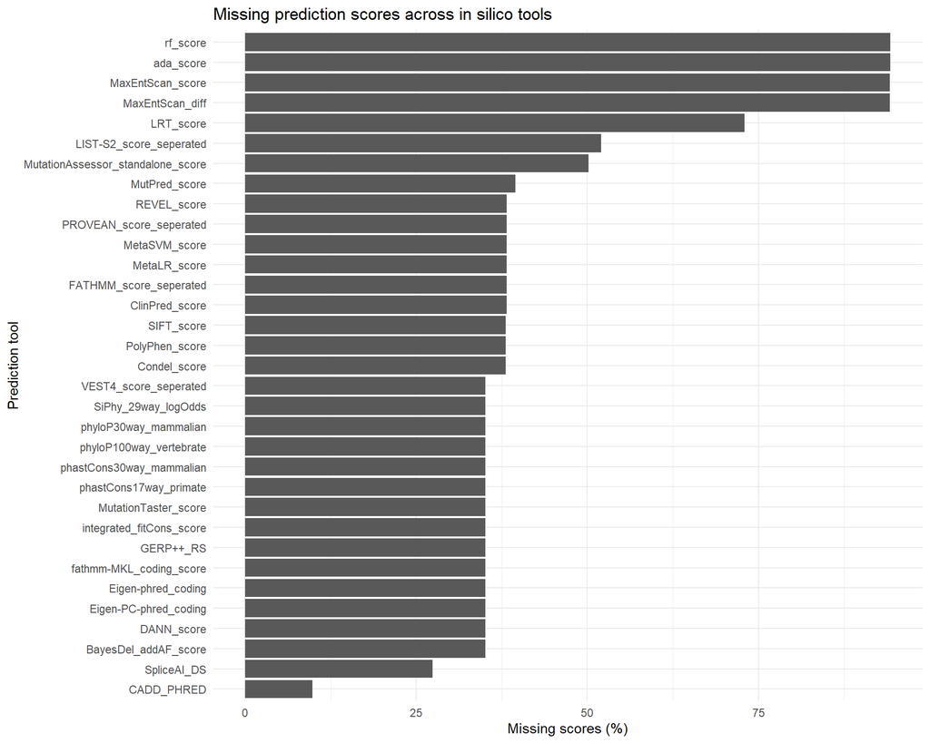

## Heatmap of mean tool scores by pathogenicity class

It summarises the average prediction scores of selected tools across pathogenicty classes in order to visualise whther prediction scores differ between B/LB. P/LP and VUS

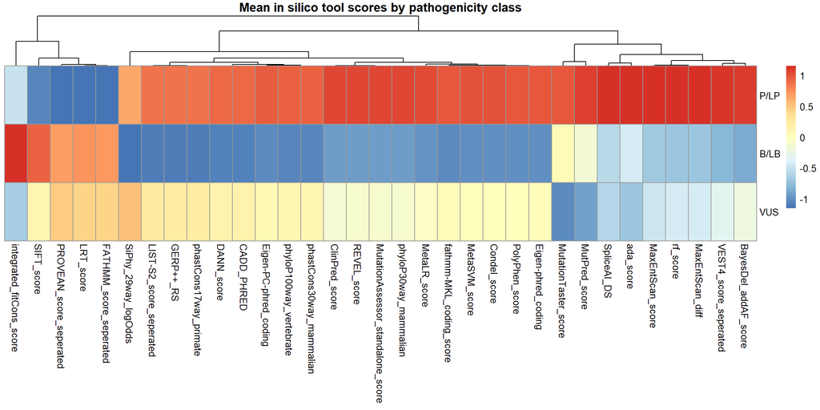

# Analysis of Genes against the pathogenicty

```r
gene_variant_type_summary <- as.data.frame(
  table(
    DATASET_FOR_PROJECT$HGVS,
    DATASET_FOR_PROJECT$Effect_function
  )
)

colnames(gene_variant_type_summary) <- c(
  "HGVS",
  "Effect_function",
  "n"
)

gene_variant_type_summary <- gene_variant_type_summary[
  gene_variant_type_summary$n > 0,
]

gene_variant_type_summary
```

```
##                                               HGVS
## 1                                    HBA1:c.-15C>G
## 2                                    HBA1:c.-16T>C
## 3                                    HBA1:c.-24C>G
## 5                                     HBA1:c.-9G>C
## 249                                  HBA2:c.-15C>G
## 250                                  HBA2:c.-24C>G
## 251                                  HBA2:c.-27T>A
## 257                                   HBA2:c.-8A>C
## 600                            HBB:c.-11_-8delAAAC
## 627                                   HBB:c.-18C>G
## 628                                   HBB:c.-21T>A
## 631                                   HBB:c.-24C>G
## 633                                   HBB:c.-29G>A
## 634                                   HBB:c.-29G>T
```

[output cut: 3241 more lines]

#visualization

[figure not shown]

#Distribution of Effect Function

```r
effect_function_counts <- as.data.frame(
  table(DATASET_FOR_PROJECT$Effect_function)
)

colnames(effect_function_counts) <- c(
  "Effect_function",
  "n"
)

effect_function_counts <- effect_function_counts[
  order(effect_function_counts$n, decreasing = TRUE),
]

effect_function_counts$percentage <- round(
  effect_function_counts$n / sum(effect_function_counts$n) * 100,
  1
)

effect_function_counts
```

```
##                                           Effect_function    n percentage
## 13                                        Missense codons 1003       61.6
## 7                                              Frameshift  195       12.0
## 8                                          Inframe indels   68        4.2
## 16                                               Promoter   61        3.7
## 29                                            Stop gained   51        3.1
## 23                 Splice region variant; Missense codons   34        2.1
## 1                                                   5'UTR   22        1.4
## 20                                  Splice region variant   22        1.4
## 31                                Synonymous substitution   21        1.3
## 9                                        Initiation codon   19        1.2
## 19                                           Splice donor   19        1.2
## 18                                        Splice acceptor   17        1.0
## 17                          RNA cleavage - Poly(A) signal   16        1.0
## 15                                       Other 3'UTR site   15        0.9
```

[output cut: 17 more lines]

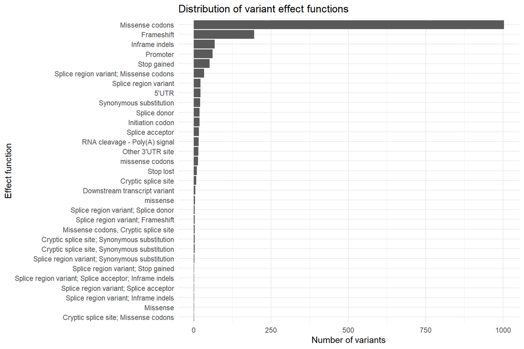

##importing of results of ensembl vep for analysis

```r
excel_files <- list.files(
  path = ".",
  pattern = "\\.xlsx$",
  recursive = TRUE,
  full.names = TRUE,
  ignore.case = TRUE
)

excel_files
```

```
## [1] "./DATASET FOR PROJECT.xlsx"
## [2] "./dataset_with_parsed_GRCh37_coordinates.xlsx"
## [3] "./haemoglobinopathy-variant/data/processed/ENSEMBL_VEP_OUTPUT.xlsx"
## [4] "./haemoglobinopathy-variant/data/raw/DATASET FOR PROJECT.xlsx"
## [5] "./haemoglobinopathy-variant/DATASET FOR PROJECT.xlsx"
## [6] "./haemoglobinopathy-variant/ENSEMBL_VEP_OUTPUT.xlsx"
## [7] "./OUTPUT_OF_VARIANTS.xlsx"
## [8] "./vep output1.xlsx"
```

```r
DATASET_FOR_PROJECT <- readxl::read_excel(
  "C:/Users/HP/Documents/ASSESSMENT OF IN SILICO TOOLS FOR VARIANT EFFECT PREDICTION IN HAEMOGLOBINOPATHIES/haemoglobinopathy-variant/DATASET FOR PROJECT.xlsx"
)

dim(DATASET_FOR_PROJECT)
```

```
## [1] 1627   45
```

```r
names(DATASET_FOR_PROJECT)
```

```
##  [1] "ithaID"                            "changes"
##  [3] "Vep_input"                         "GRCh38 Vep_input"
##  [5] "HGVS"                              "HGVS_transcript"
##  [7] "HGVS_protein"                      "Initial_observed_pathogenicity"
##  [9] "Observed_pathogenicity"            "Effect_function"
## [11] "Location"                          "Consequence"
## [13] "SIFT_score"                        "integrated_fitCons_score"
## [15] "MutationTaster_score"              "LRT_score"
## [17] "PolyPhen_score"                    "SpliceAI_DS"
## [19] "ClinPred_score"                    "DANN_score"
## [21] "LIST-S2_score_seperated"           "MetaSVM_score"
## [23] "MutPred_score"                     "REVEL_score"
## [25] "VEST4_score_seperated"             "fathmm-MKL_coding_score"
## [27] "ada_score"                         "rf_score"
## [29] "Condel_score"                      "MetaLR_score"
## [31] "GERP++_RS"                         "Eigen-PC-phred_coding"
## [33] "BayesDel_addAF_score"              "FATHMM_score_seperated"
## [35] "MutationAssessor_standalone_score" "PROVEAN_score_seperated"
## [37] "CADD_PHRED"                        "phyloP100way_vertebrate"
## [39] "phyloP30way_mammalian"             "phastCons30way_mammalian"
## [41] "phastCons17way_primate"            "SiPhy_29way_logOdds"
## [43] "Eigen-phred_coding"                "MaxEntScan_diff"
## [45] "MaxEntScan_score"
```

```r
ENSEMBL_VEP_OUTPUT <- readr::read_csv(
  "C:/Users/HP/Documents/ASSESSMENT OF IN SILICO TOOLS FOR VARIANT EFFECT PREDICTION IN HAEMOGLOBINOPATHIES/haemoglobinopathy-variant/ENSEMBL_VEP_OUTPUT.csv",
  show_col_types = FALSE,
  trim_ws = TRUE
)

dim(ENSEMBL_VEP_OUTPUT)
```

```
## [1] 64562   594
```

```r
names(ENSEMBL_VEP_OUTPUT)
```

```
##   [1] "#Uploaded_variation"
##   [2] "Location"
##   [3] "Allele"
##   [4] "Consequence"
##   [5] "IMPACT"
##   [6] "SYMBOL"
##   [7] "Gene"
##   [8] "Feature_type"
##   [9] "Feature"
##  [10] "BIOTYPE"
##  [11] "EXON"
##  [12] "INTRON"
##  [13] "HGVSc"
##  [14] "HGVSp"
##  [15] "cDNA_position"
```

[output cut: 579 more lines]

```r
# Inspect likely variant identifier columns
possible_vep_id_columns <- grep(
  "uploaded|variation|vep",
  names(ENSEMBL_VEP_OUTPUT),
  value = TRUE,
  ignore.case = TRUE
)

possible_vep_id_columns
```

```
## [1] "#Uploaded_variation" "Existing_variation"  "UPLOADED_ALLELE"
```

```r
# Standardise the uploaded variant identifier to vep_input
if ("vep_input" %in% names(ENSEMBL_VEP_OUTPUT)) {

  message(
    "Column already named vep_input; no renaming required."
  )

} else if ("Uploaded_variation" %in% names(ENSEMBL_VEP_OUTPUT)) {

  ENSEMBL_VEP_OUTPUT <- ENSEMBL_VEP_OUTPUT %>%
    rename(
      vep_input = Uploaded_variation
    )

} else if ("#Uploaded_variation" %in% names(ENSEMBL_VEP_OUTPUT)) {

  ENSEMBL_VEP_OUTPUT <- ENSEMBL_VEP_OUTPUT %>%
    rename(
      vep_input = `#Uploaded_variation`)} else {

  stop(
    paste(
      "Could not find the VEP uploaded-variant identifier.",
      "Available candidate columns:",
      paste(possible_vep_id_columns, collapse = ", ")))}

# Confirm successful creation
"vep_input" %in%
  names(ENSEMBL_VEP_OUTPUT)
```

```
## [1] TRUE
```

```r
ENSEMBL_VEP_OUTPUT <- ENSEMBL_VEP_OUTPUT %>%
  mutate(
    vep_input = trimws(
      as.character(vep_input)
    )
  )
```

##inspection of the dataset to ensure that it was imported correctly

```r
dim(ENSEMBL_VEP_OUTPUT)
```

```
## [1] 64562   594
```

```r
head(ENSEMBL_VEP_OUTPUT, 5)
```

```
## # A tibble: 5 × 594
##   vep_input Location Allele Consequence IMPACT SYMBOL Gene  Feature_type Feature
##   <chr>     <chr>    <chr>  <chr>       <chr>  <chr>  <chr> <chr>        <chr>
## 1 NC_00001… 11:5226… C      missense_v… MODER… HBB    ENSG… Transcript   ENST00…
## 2 NC_00001… 11:5226… C      missense_v… MODER… HBB    ENSG… Transcript   ENST00…
## 3 NC_00001… 11:5226… C      upstream_g… MODIF… -      ENSG… Transcript   ENST00…
## 4 NC_00001… 11:5226… C      upstream_g… MODIF… HBB    ENSG… Transcript   ENST00…
## 5 NC_00001… 11:5226… C      missense_v… MODER… HBB    ENSG… Transcript   ENST00…
## # ℹ 585 more variables: BIOTYPE <chr>, EXON <chr>, INTRON <chr>, HGVSc <chr>,
## #   HGVSp <chr>, cDNA_position <chr>, CDS_position <chr>,
## #   Protein_position <chr>, Amino_acids <chr>, Codons <chr>,
## #   Existing_variation <chr>, REF_ALLELE <chr>, UPLOADED_ALLELE <chr>,
## #   DISTANCE <chr>, STRAND <dbl>, FLAGS <chr>, SYMBOL_SOURCE <chr>,
## #   HGNC_ID <chr>, MANE <chr>, MANE_SELECT <chr>, MANE_PLUS_CLINICAL <chr>,
## #   TSL <chr>, APPRIS <chr>, SIFT <chr>, PolyPhen <chr>, AF <chr>, …
```

##standardise the columns in order to reduce the chances of errors and make merging easier and seamless

```r
# Remove a leading # from VEP column names
names(ENSEMBL_VEP_OUTPUT) <- sub(
  "^#",
  "",
  names(ENSEMBL_VEP_OUTPUT)
)

# Convert spaces and punctuation to underscores
names(ENSEMBL_VEP_OUTPUT) <- gsub(
  "[^A-Za-z0-9_]+",
  "_",
  names(ENSEMBL_VEP_OUTPUT)
)

# Remove leading or trailing underscores
names(ENSEMBL_VEP_OUTPUT) <- gsub(
  "^_|_$",
  "",
  names(ENSEMBL_VEP_OUTPUT)
)

# Inspect cleaned column names
names(ENSEMBL_VEP_OUTPUT)
```

```
##   [1] "vep_input"
##   [2] "Location"
##   [3] "Allele"
##   [4] "Consequence"
##   [5] "IMPACT"
##   [6] "SYMBOL"
##   [7] "Gene"
##   [8] "Feature_type"
##   [9] "Feature"
##  [10] "BIOTYPE"
##  [11] "EXON"
##  [12] "INTRON"
##  [13] "HGVSc"
##  [14] "HGVSp"
##  [15] "cDNA_position"
```

[output cut: 579 more lines]

## this is to determine the overlap between original ddataset and the output from ver, checking how many unique variants from the original dataset are present in the new VEP output including the total datset rows number of unique GHCh38 variants, the number found in vep and number not found and the percentage found

```r
variant_overlap <- DATASET_FOR_PROJECT %>%
  summarise(

    total_rows = n(),

    unique_original_variants = n_distinct(
      .data[["GRCh38 Vep_input"]],
      na.rm = TRUE
    ),

    variants_found_in_vep = n_distinct(
      .data[["GRCh38 Vep_input"]][
        !is.na(.data[["GRCh38 Vep_input"]]) &
        .data[["GRCh38 Vep_input"]] %in%
          ENSEMBL_VEP_OUTPUT$vep_input
      ],
      na.rm = TRUE
    ),

    variants_not_found_in_vep = n_distinct(
      .data[["GRCh38 Vep_input"]][
        !is.na(.data[["GRCh38 Vep_input"]]) &
        !.data[["GRCh38 Vep_input"]] %in%
          ENSEMBL_VEP_OUTPUT$vep_input
      ],
      na.rm = TRUE
    )
  ) %>%

  mutate(
    percent_found_in_vep = round(
      variants_found_in_vep /
        unique_original_variants * 100,
      1
    )
  )

variant_overlap
```

```
## # A tibble: 1 × 5
##   total_rows unique_original_vari…¹ variants_found_in_vep variants_not_found_i…²
##        <int>                  <int>                 <int>                  <int>
## 1       1627                   1616                  1616                      0
## # ℹ abbreviated names: ¹unique_original_variants, ²variants_not_found_in_vep
## # ℹ 1 more variable: percent_found_in_vep <dbl>
```

## identification the variants not found in VEP

```r
unmatched_variants <- DATASET_FOR_PROJECT %>%
  filter(
    !is.na(.data[["GRCh38 Vep_input"]]),
    .data[["GRCh38 Vep_input"]] != ""
  ) %>%
  anti_join(
    ENSEMBL_VEP_OUTPUT %>%
      distinct(vep_input),
    by = c(
      "GRCh38 Vep_input" = "vep_input"
    )
  )

nrow(unmatched_variants)
```

```
## [1] 0
```

```r
head(unmatched_variants, 10)
```

```
## # A tibble: 0 × 45
## # ℹ 45 variables: ithaID <dbl>, changes <lgl>, Vep_input <chr>,
## #   GRCh38 Vep_input <chr>, HGVS <chr>, HGVS_transcript <chr>,
## #   HGVS_protein <chr>, Initial_observed_pathogenicity <chr>,
## #   Observed_pathogenicity <chr>, Effect_function <chr>, Location <chr>,
## #   Consequence <chr>, SIFT_score <dbl>, integrated_fitCons_score <dbl>,
## #   MutationTaster_score <dbl>, LRT_score <dbl>, PolyPhen_score <dbl>,
## #   SpliceAI_DS <dbl>, ClinPred_score <dbl>, DANN_score <dbl>, …
```

## determine whether a variant in the VEP analysis contained any repeated rows

```r
vep_duplicate_check <- ENSEMBL_VEP_OUTPUT %>%
  count(
    vep_input,
    name = "n_vep_rows"
  ) %>%
  arrange(
    desc(n_vep_rows)
  )

head(
  vep_duplicate_check,
  20
)
```

```
## # A tibble: 20 × 2
##    vep_input                       n_vep_rows
##    <chr>                                <int>
##  1 NC_000016.10:g.176786G>C               144
##  2 NC_000016.10:g.177056G>A               144
##  3 NC_000016.10:g.173186_173209del        138
##  4 NC_000016.10:g.176675C>T                73
##  5 NC_000016.10:g.176693C>G                73
##  6 NC_000016.10:g.176701T>C                73
##  7 NC_000016.10:g.176702C>G                73
##  8 NC_000016.10:g.176708G>C                73
##  9 NC_000016.10:g.177545dup                73
## 10 NC_000016.10:g.176717A>G                72
## 11 NC_000016.10:g.176718T>A                72
## 12 NC_000016.10:g.176718del                72
## 13 NC_000016.10:g.176720G>T                72
## 14 NC_000016.10:g.176723_176725dup         72
## 15 NC_000016.10:g.176724T>C                72
## 16 NC_000016.10:g.176724T>G                72
## 17 NC_000016.10:g.176727C>T                72
## 18 NC_000016.10:g.176733C>A                72
## 19 NC_000016.10:g.176735G>C                72
## 20 NC_000016.10:g.176735G>T                72
```

## determining the number of variants which have multiple rows and their percentages

```r
vep_duplicate_summary <- tibble(

  total_unique_variants = nrow(
    vep_duplicate_check
  ),

  variants_with_multiple_rows = sum(
    vep_duplicate_check$n_vep_rows > 1
  ),

  variants_with_single_row = sum(
    vep_duplicate_check$n_vep_rows == 1
  ),

  percentage_with_multiple_rows = round(
    mean(
      vep_duplicate_check$n_vep_rows > 1
    ) * 100,
    1
  )
)

vep_duplicate_summary
```

```
## # A tibble: 1 × 4
##   total_unique_variants variants_with_multiple_rows variants_with_single_row
##                   <int>                       <int>                    <int>
## 1                  1616                        1616                        0
## # ℹ 1 more variable: percentage_with_multiple_rows <dbl>
```

##preparing the merging of both existing and new data to ensure a seamless workflow Before merging both datasets were inspected to confirm the availability of appropriate variant,gene, and transcript identifiers with the original dataset (DATASET_FOR_PROJECT) considered as the reference dataset where updated GRCh 38 variants added to it. the existence of both objects were confirmed before proceeding

```r
exists("DATASET_FOR_PROJECT")
```

```
## [1] TRUE
```

```r
exists("ENSEMBL_VEP_OUTPUT")
```

```
## [1] TRUE
```

## To provide a baseline to determine whether the merge unexpectedly increases the number of rows, the dimensions of both datasets are examined before merging

```r
dim(DATASET_FOR_PROJECT)
```

```
## [1] 1627   45
```

```r
dim(ENSEMBL_VEP_OUTPUT)
```

```
## [1] 64562   594
```

## the column names were inspected in order to identify the variables required to match the datasets with particular attention given to genomic variant identifiers, gene symbol,transcript identifiers and MANE select annotations

```r
names(DATASET_FOR_PROJECT)
```

```
##  [1] "ithaID"                            "changes"
##  [3] "Vep_input"                         "GRCh38 Vep_input"
##  [5] "HGVS"                              "HGVS_transcript"
##  [7] "HGVS_protein"                      "Initial_observed_pathogenicity"
##  [9] "Observed_pathogenicity"            "Effect_function"
## [11] "Location"                          "Consequence"
## [13] "SIFT_score"                        "integrated_fitCons_score"
## [15] "MutationTaster_score"              "LRT_score"
## [17] "PolyPhen_score"                    "SpliceAI_DS"
## [19] "ClinPred_score"                    "DANN_score"
## [21] "LIST-S2_score_seperated"           "MetaSVM_score"
## [23] "MutPred_score"                     "REVEL_score"
## [25] "VEST4_score_seperated"             "fathmm-MKL_coding_score"
## [27] "ada_score"                         "rf_score"
## [29] "Condel_score"                      "MetaLR_score"
## [31] "GERP++_RS"                         "Eigen-PC-phred_coding"
## [33] "BayesDel_addAF_score"              "FATHMM_score_seperated"
## [35] "MutationAssessor_standalone_score" "PROVEAN_score_seperated"
## [37] "CADD_PHRED"                        "phyloP100way_vertebrate"
## [39] "phyloP30way_mammalian"             "phastCons30way_mammalian"
## [41] "phastCons17way_primate"            "SiPhy_29way_logOdds"
## [43] "Eigen-phred_coding"                "MaxEntScan_diff"
## [45] "MaxEntScan_score"
```

```r
names(ENSEMBL_VEP_OUTPUT)
```

```
##   [1] "vep_input"
##   [2] "Location"
##   [3] "Allele"
##   [4] "Consequence"
##   [5] "IMPACT"
##   [6] "SYMBOL"
##   [7] "Gene"
##   [8] "Feature_type"
##   [9] "Feature"
##  [10] "BIOTYPE"
##  [11] "EXON"
##  [12] "INTRON"
##  [13] "HGVSc"
##  [14] "HGVSp"
##  [15] "cDNA_position"
```

[output cut: 579 more lines]

## the variant identifier in the ENSEMBL VEP OUTPUT was identified and renamed to simplify subsequent matching and joining operations

```r
grep(
  "uploaded|variation|vep",
  names(ENSEMBL_VEP_OUTPUT),
  value = TRUE,
  ignore.case = TRUE)
```

```
## [1] "vep_input"          "Existing_variation" "UPLOADED_ALLELE"
```

```r
candidate_vep_id <- grep(
  "uploaded.*variation|variation.*uploaded",
  names(ENSEMBL_VEP_OUTPUT),
  value = TRUE,
  ignore.case = TRUE
)

if ("vep_input" %in% names(ENSEMBL_VEP_OUTPUT)) {

  message("vep_input already exists; no renaming required.")

} else if (length(candidate_vep_id) == 1) {

  names(ENSEMBL_VEP_OUTPUT)[
    names(ENSEMBL_VEP_OUTPUT) == candidate_vep_id
  ] <- "vep_input"

} else {

  stop(
    paste0(
      "Could not uniquely identify the uploaded VEP variant column. ",
      "Candidates found: ",
      paste(candidate_vep_id, collapse = ", ")) )}
```

```
## vep_input already exists; no renaming required.
```

```r
"vep_input" %in%
  names(ENSEMBL_VEP_OUTPUT)
```

```
## [1] TRUE
```

```r
  head(
  ENSEMBL_VEP_OUTPUT$vep_input,
  10)
```

```
##  [1] "NC_000011.10:g.5226963T>C" "NC_000011.10:g.5226963T>C"
##  [3] "NC_000011.10:g.5226963T>C" "NC_000011.10:g.5226963T>C"
##  [5] "NC_000011.10:g.5226963T>C" "NC_000011.10:g.5226963T>C"
##  [7] "NC_000011.10:g.5226963T>C" "NC_000011.10:g.5226963T>C"
##  [9] "NC_000011.10:g.5226963T>C" "NC_000011.10:g.5226963T>C"
```

```r
ENSEMBL_VEP_OUTPUT <- ENSEMBL_VEP_OUTPUT %>%
  mutate(
    MANE_transcript_base = sub(
      "\\.[0-9]+$",
      "",
      MANE_SELECT))
```

```r
head(
  ENSEMBL_VEP_OUTPUT[
    c(
      "vep_input",
      "SYMBOL",
      "MANE_SELECT",
      "MANE_transcript_base" )],10)
```

```
## # A tibble: 10 × 4
##    vep_input                 SYMBOL MANE_SELECT MANE_transcript_base
##    <chr>                     <chr>  <chr>       <chr>
##  1 NC_000011.10:g.5226963T>C HBB    NM_000518.5 NM_000518
##  2 NC_000011.10:g.5226963T>C HBB    -           -
##  3 NC_000011.10:g.5226963T>C -      -           -
##  4 NC_000011.10:g.5226963T>C HBB    -           -
##  5 NC_000011.10:g.5226963T>C HBB    -           -
##  6 NC_000011.10:g.5226963T>C HBB    -           -
##  7 NC_000011.10:g.5226963T>C -      -           -
##  8 NC_000011.10:g.5226963T>C HBB    -           -
##  9 NC_000011.10:g.5226963T>C -      -           -
## 10 NC_000011.10:g.5226963T>C HBB    -           -
```

```r
VEP_MANE <- ENSEMBL_VEP_OUTPUT %>%
  filter(
    !is.na(MANE_SELECT),
    MANE_SELECT != "-"
  )
```

```r
VEP_TARGET <- VEP_MANE %>%
  filter(
    SYMBOL %in% c(
      "HBA1",
      "HBA2",
      "HBB"
    )
  )
```

```r
VEP_TARGET_DEDUP <- VEP_TARGET %>%
  distinct(
    vep_input,
    SYMBOL,
    Feature_type,
    Feature,
    MANE_SELECT,
    Consequence,
    .keep_all = TRUE
  )
```

```r
vep_key_check <- VEP_TARGET_DEDUP %>%
  count(
    vep_input,
    SYMBOL,
    MANE_transcript_base,
    name = "n_rows_per_key"
  ) %>%
  arrange(
    desc(n_rows_per_key)
  )

head(
  vep_key_check,
  20
)
```

```
## # A tibble: 20 × 4
##    vep_input                          SYMBOL MANE_transcript_base n_rows_per_key
##    <chr>                              <chr>  <chr>                         <int>
##  1 NC_000011.10:g.5225337A>G          HBB    NM_000518                         1
##  2 NC_000011.10:g.5225365C>G          HBB    NM_000518                         1
##  3 NC_000011.10:g.5225416C>T          HBB    NM_000518                         1
##  4 NC_000011.10:g.5225463A>T          HBB    NM_000518                         1
##  5 NC_000011.10:g.5225480T>C          HBB    NM_000518                         1
##  6 NC_000011.10:g.5225485T>C          HBB    NM_000518                         1
##  7 NC_000011.10:g.5225486T>A          HBB    NM_000518                         1
##  8 NC_000011.10:g.5225486T>C          HBB    NM_000518                         1
##  9 NC_000011.10:g.5225486_5225487del  HBB    NM_000518                         1
## 10 NC_000011.10:g.5225486_5225490del  HBB    NM_000518                         1
## 11 NC_000011.10:g.5225487T>C          HBB    NM_000518                         1
## 12 NC_000011.10:g.5225488A>G          HBB    NM_000518                         1
## 13 NC_000011.10:g.5225488A>T          HBB    NM_000518                         1
## 14 NC_000011.10:g.5225488_5225489del  HBB    NM_000518                         1
## 15 NC_000011.10:g.5225490T>C          HBB    NM_000518                         1
## 16 NC_000011.10:g.5225490T>G          HBB    NM_000518                         1
## 17 NC_000011.10:g.5225494C>T          HBB    NM_000518                         1
## 18 NC_000011.10:g.5225495_5225502del… HBB    NM_000518                         1
## 19 NC_000011.10:g.5225495_5225507del  HBB    NM_000518                         1
## 20 NC_000011.10:g.5225502A>G          HBB    NM_000518                         1
```

```r
n_non_unique_vep_keys <- sum(
  vep_key_check$n_rows_per_key > 1
)

n_non_unique_vep_keys
```

```
## [1] 0
```

```r
DATASET_FOR_PROJECT <- DATASET_FOR_PROJECT %>%
  mutate(
    original_row_id = row_number()
  )
```

## derivation of gene symbols from the HGVS descriptions and inspect them

```r
DATASET_FOR_PROJECT <- DATASET_FOR_PROJECT %>%
  mutate(

    HGVS_prefix = sub(
      ":.*$",
      "",
      HGVS
    ),

    Gene = case_when(

      HGVS_prefix %in% c(
        "HBA1",
        "HBA2",
        "HBB"
      ) ~ HGVS_prefix,

      grepl(
        "^NM_000558(\\.|$)",
        HGVS_prefix
      ) ~ "HBA1",

      grepl(
        "^NM_000517(\\.|$)",
        HGVS_prefix
      ) ~ "HBA2",

      grepl(
        "^NM_000518(\\.|$)",
        HGVS_prefix
      ) ~ "HBB",

      TRUE ~ NA_character_))
```

```r
table(
  DATASET_FOR_PROJECT$Gene,
  useNA = "ifany"
)
```

```
##
## HBA1 HBA2  HBB <NA>
##  245  349 1010   23
```

```r
unique(
  DATASET_FOR_PROJECT$HGVS_prefix[
    is.na(DATASET_FOR_PROJECT$Gene)
  ]
)
```

```
## [1] "NG_000007.3"
```

## Assessment of variant overlap between datasets

Before merging, the overlap between the original GRCh38 variant identifiers and the Ensembl VEP output was assessed. This step determines how many unique original variants were successfully represented in the updated VEP output.

```r
variant_overlap <- DATASET_FOR_PROJECT %>%
  summarise(

    total_rows = n(),

    unique_original_variants = n_distinct(
      .data[["GRCh38 Vep_input"]],
      na.rm = TRUE
    ),

    variants_found_in_vep = n_distinct(
      .data[["GRCh38 Vep_input"]][
        .data[["GRCh38 Vep_input"]] %in%
          ENSEMBL_VEP_OUTPUT$vep_input
      ],
      na.rm = TRUE
    ),

    variants_not_found_in_vep = n_distinct(
      .data[["GRCh38 Vep_input"]][
        !.data[["GRCh38 Vep_input"]] %in%
          ENSEMBL_VEP_OUTPUT$vep_input
      ],
      na.rm = TRUE
    )
  ) %>%

  mutate(
    percent_found_in_vep = round(
      variants_found_in_vep /
        unique_original_variants * 100,
      1
    )
  )

variant_overlap
```

```
## # A tibble: 1 × 5
##   total_rows unique_original_vari…¹ variants_found_in_vep variants_not_found_i…²
##        <int>                  <int>                 <int>                  <int>
## 1       1627                   1616                  1616                      0
## # ℹ abbreviated names: ¹unique_original_variants, ²variants_not_found_in_vep
## # ℹ 1 more variable: percent_found_in_vep <dbl>
```

This summary provides an initial quality-control measure by quantifying the proportion of original GRCh38 variants represented in the updated VEP output.

## Selection of MANE Select annotations

To improve transcript consistency, VEP rows lacking a valid MANE Select transcript were excluded. MANE Select annotations were used because they provide a standardised transcript representation for downstream comparison.

```r
VEP_MANE <- ENSEMBL_VEP_OUTPUT %>%
  filter(
    !is.na(MANE_SELECT),
    MANE_SELECT != "-"
  )
```

```r
mane_summary <- VEP_MANE %>%
  summarise(

    total_mane_rows = n(),

    unique_mane_variants = n_distinct(
      vep_input
    )
  )

mane_summary
```

```
## # A tibble: 1 × 2
##   total_mane_rows unique_mane_variants
##             <int>                <int>
## 1            2480                 1616
```

## Restriction to haemoglobinopathy study genes

The primary analysis focuses on variants in `HBA1`, `HBA2`, and `HBB`. VEP annotations corresponding to other genes were therefore excluded from the main merging dataset to reduce ambiguity caused by overlapping or neighbouring gene annotations.

```r
VEP_TARGET <- VEP_MANE %>%
  filter(
    SYMBOL %in% c(
      "HBA1",
      "HBA2",
      "HBB"
    )
  )
```

## Creating the transcript family idenifier to allow for transcript family matching

```r
VEP_TARGET <- VEP_TARGET %>%
  mutate(
    MANE_transcript_base = sub(
      "\\.[0-9]+$",
      "",
      MANE_SELECT
    )
  )
```

## Removal of duplicate VEP annotations

Repeated VEP rows may occur for the same variant, gene, feature, MANE transcript, and consequence. Exact duplicates across these key annotation fields were removed before merging to reduce the risk of row multiplication during the join.

```r
VEP_TARGET_DEDUP <- VEP_TARGET %>%
  distinct(
    vep_input,
    SYMBOL,
    Feature_type,
    Feature,
    MANE_SELECT,
    Consequence,
    .keep_all = TRUE
  )
```

```r
target_gene_summary <- VEP_TARGET %>%
  count(
    SYMBOL,
    name = "n_rows"
  ) %>%
  mutate(
    percentage = round(
      n_rows / sum(n_rows) * 100,
      1
    )
  )

target_gene_summary
```

```
## # A tibble: 3 × 3
##   SYMBOL n_rows percentage
##   <chr>   <int>      <dbl>
## 1 HBA1      594       26.7
## 2 HBA2      594       26.7
## 3 HBB      1033       46.5
```

## this is to determine if the removal of duplicate VEP anotation change the dataset by comparing the VEP target before deplication with it after deduplication

```r
dedup_summary <- tibble(

  rows_before_dedup =
    nrow(VEP_TARGET),

  rows_after_dedup =
    nrow(VEP_TARGET_DEDUP),

  rows_removed =
    nrow(VEP_TARGET) -
    nrow(VEP_TARGET_DEDUP),

  unique_variants_after_dedup =
    n_distinct(
      VEP_TARGET_DEDUP$vep_input
    )
)

dedup_summary
```

```
## # A tibble: 1 × 4
##   rows_before_dedup rows_after_dedup rows_removed unique_variants_after_dedup
##               <int>            <int>        <int>                       <int>
## 1              2221             2207           14                        1616
```

## preparing of VEP columns for merging to make it easy to distinguish it from existing columns in the original dataset

```r
VEP_FOR_MERGE <- VEP_TARGET_DEDUP %>%
  rename_with(
    .fn = ~ paste0(.x, "_new"),
    .cols = -c(
      vep_input,
      SYMBOL,
      MANE_transcript_base ))
```

```r
DATASET_FOR_PROJECT <- DATASET_FOR_PROJECT %>%
  mutate(

    Original_transcript = sub(
      ":.*$",
      "",
      HGVS_transcript
    ),

    Original_transcript_base = sub(
      "\\.[0-9]+$",
      "",
      Original_transcript))
```

```r
head(
  DATASET_FOR_PROJECT[
    c(
      "HGVS_transcript",
      "Original_transcript",
      "Original_transcript_base"
    )
  ],
  10
)
```

```
## # A tibble: 10 × 3
##    HGVS_transcript       Original_transcript Original_transcript_base
##    <chr>                 <chr>               <chr>
##  1 NM_000518.4:c.-240G>A NM_000518.4         NM_000518
##  2 NM_000518.4:c.-152C>A NM_000518.4         NM_000518
##  3 NM_000518.4:c.-151C>T NM_000518.4         NM_000518
##  4 NM_000518.4:c.-151C>G NM_000518.4         NM_000518
##  5 NM_000518.4:c.-143C>G NM_000518.4         NM_000518
##  6 NM_000518.4:c.-142C>T NM_000518.4         NM_000518
##  7 NM_000518.4:c.-140C>T NM_000518.4         NM_000518
##  8 NM_000518.4:c.-138C>T NM_000518.4         NM_000518
##  9 NM_000518.4:c.-138C>A NM_000518.4         NM_000518
## 10 NM_000518.4:c.-137C>G NM_000518.4         NM_000518
```

#Merging of both datasets using the left join as VEP side key is unique

```r
MERGED_DATASET <- DATASET_FOR_PROJECT %>%
  left_join(
    VEP_FOR_MERGE,
    by = c(
      "GRCh38 Vep_input" = "vep_input",
      "Gene" = "SYMBOL",
      "Original_transcript_base" = "MANE_transcript_base"))
```

```r
merge_row_check <- tibble(
  original_rows = nrow(DATASET_FOR_PROJECT),
  merged_rows = nrow(MERGED_DATASET),
  row_count_unchanged =
    nrow(DATASET_FOR_PROJECT) ==
    nrow(MERGED_DATASET)
)

merge_row_check
```

```
## # A tibble: 1 × 3
##   original_rows merged_rows row_count_unchanged
##           <int>       <int> <lgl>
## 1          1627        1627 TRUE
```

```r
duplicated_original_rows <- MERGED_DATASET %>%
  count(
    original_row_id,
    name = "n_rows_after_join"
  ) %>%
  filter(
    n_rows_after_join > 1
  )

nrow(
  duplicated_original_rows
)
```

```
## [1] 0
```

##determing of how many rows actually matched

```r
merge_match_summary <- MERGED_DATASET %>%
  summarise(
    total_rows = n(),
    matched_rows = sum(
      !is.na(MANE_SELECT_new)
    ),
    unmatched_rows = sum(
      is.na(MANE_SELECT_new)
    ),
    percent_matched = round(
      mean(
        !is.na(MANE_SELECT_new)
      ) * 100,
      1
    )
  )

merge_match_summary
```

```
## # A tibble: 1 × 4
##   total_rows matched_rows unmatched_rows percent_matched
##        <int>        <int>          <int>           <dbl>
## 1       1627         1604             23            98.6
```

```r
# output_directory is already defined near the top of the notebook

if (!dir.exists(output_directory)) {
  dir.create(output_directory, recursive = TRUE)
}

readr::write_csv(
  MERGED_DATASET,
  file.path(output_directory, "MERGED_DATASET.csv")
)

saveRDS(
  MERGED_DATASET,
  file.path(output_directory, "MERGED_DATASET.rds")
)
```

#identification of unmatched records after merging to determine if failed merging resulted from either genomic identifier differences, gene assignment descrepancies,transcript family differences or missing MANE Select annotations

```r
UNMATCHED_AFTER_MERGE <- MERGED_DATASET %>%
  filter(
    is.na(MANE_SELECT_new)
  )

nrow(UNMATCHED_AFTER_MERGE)
```

```
## [1] 23
```

### inspection of relevant identifiers

```r
UNMATCHED_AFTER_MERGE %>%
  select(
    original_row_id,
    `GRCh38 Vep_input`,
    HGVS,
    HGVS_prefix,
    Gene,
    HGVS_transcript,
    Original_transcript,
    Original_transcript_base
  ) %>%
  print(
    n = Inf,
    width = Inf
  )
```

```
## # A tibble: 23 × 8
##    original_row_id `GRCh38 Vep_input`
##              <int> <chr>
##  1             117 NC_000011.10:g.5226788_5226809dup
##  2             199 NC_000011.10:g.5226573_5226574del
##  3            1074 NC_000011.10:g.5227540G>A
##  4            1075 NC_000011.10:g.5227411G>A
##  5            1076 NC_000011.10:g.5227125C>T
##  6            1077 NC_000011.10:g.5227113G>C
##  7            1078 NC_000011.10:g.5227013A>G
##  8            1079 NC_000011.10:g.5226932G>C
##  9            1080 NC_000011.10:g.5226914T>G
## 10            1082 NC_000011.10:g.5226837C>T
## 11            1083 NC_000011.10:g.5226784G>A
## 12            1084 NC_000011.10:g.5226739A>T
```

[output cut: 61 more lines]

```r
UNMATCHED_AFTER_MERGE %>%
  count(
    Original_transcript_base,
    name = "n_records") %>%
  arrange(
    desc(n_records))
```

```
## # A tibble: 1 × 2
##   Original_transcript_base n_records
##   <chr>                        <int>
## 1 NG_000007                       23
```

```r
UNMATCHED_VEP_ASSIGNMENTS <- UNMATCHED_AFTER_MERGE %>%
  select(
    original_row_id,
    `GRCh38 Vep_input`,
    HGVS,
    HGVS_prefix
  ) %>%
  left_join(
    ENSEMBL_VEP_OUTPUT %>%
      select(
        vep_input,
        SYMBOL,
        MANE_SELECT,
        Consequence,
        Feature_type,
        Feature
      ),
    by = c(
      "GRCh38 Vep_input" = "vep_input"))
```

```r
UNMATCHED_VEP_ASSIGNMENTS %>%
  count(
    SYMBOL,
    MANE_SELECT,
    name = "n_rows"
  ) %>%
  arrange(
    desc(n_rows) )
```

```
## # A tibble: 3 × 3
##   SYMBOL MANE_SELECT n_rows
##   <chr>  <chr>        <int>
## 1 HBB    -              486
## 2 -      -               81
## 3 HBB    NM_000518.5     27
```

```r
unmatched_hbb_mane_summary <- UNMATCHED_VEP_ASSIGNMENTS %>%
  filter(
    SYMBOL == "HBB",
    MANE_SELECT == "NM_000518.5"
  ) %>%
  summarise(
    total_annotation_rows = n(),
    unique_original_rows = n_distinct(
      original_row_id
    ),
    unique_genomic_variants = n_distinct(
      `GRCh38 Vep_input`
    )
  )

unmatched_hbb_mane_summary
```

```
## # A tibble: 1 × 3
##   total_annotation_rows unique_original_rows unique_genomic_variants
##                   <int>                <int>                   <int>
## 1                    27                   23                      23
```

```r
unmatched_hbb_mane_coverage <- UNMATCHED_AFTER_MERGE %>%
  select(
    original_row_id,
    `GRCh38 Vep_input`,
    HGVS
  ) %>%
  mutate(
    has_hbb_mane_assignment =
      `GRCh38 Vep_input` %in%
      (
        UNMATCHED_VEP_ASSIGNMENTS %>%
          filter(
            SYMBOL == "HBB",
            MANE_SELECT == "NM_000518.5"
          ) %>%
          pull(
            `GRCh38 Vep_input`
          )
      )
  )

unmatched_hbb_mane_coverage %>%
  count(
    has_hbb_mane_assignment)
```

```
## # A tibble: 1 × 2
##   has_hbb_mane_assignment     n
##   <lgl>                   <int>
## 1 TRUE                       23
```

```r
unmatched_hbb_mane_coverage %>%
  filter(
    !has_hbb_mane_assignment
  ) %>%
  print(
    n = Inf,
    width = Inf )
```

```
## # A tibble: 0 × 4
## # ℹ 4 variables: original_row_id <int>, GRCh38 Vep_input <chr>, HGVS <chr>, has_hbb_mane_assignment <lgl>
```

```r
hbb_mane_assignment_check <- UNMATCHED_VEP_ASSIGNMENTS %>%
  filter(
    SYMBOL == "HBB",
    MANE_SELECT == "NM_000518.5"
  ) %>%
  distinct(
    original_row_id,
    `GRCh38 Vep_input`,
    SYMBOL,
    MANE_SELECT
  ) %>%
  count(
    original_row_id,
    `GRCh38 Vep_input`,
    name = "n_distinct_hbb_mane_assignments"
  )

hbb_mane_assignment_check %>%
  print(
    n = Inf )
```

```
## # A tibble: 23 × 3
##    original_row_id `GRCh38 Vep_input`                n_distinct_hbb_mane_assig…¹
##              <int> <chr>                                                   <int>
##  1             117 NC_000011.10:g.5226788_5226809dup                           1
##  2             199 NC_000011.10:g.5226573_5226574del                           1
##  3            1074 NC_000011.10:g.5227540G>A                                   1
##  4            1075 NC_000011.10:g.5227411G>A                                   1
##  5            1076 NC_000011.10:g.5227125C>T                                   1
##  6            1077 NC_000011.10:g.5227113G>C                                   1
##  7            1078 NC_000011.10:g.5227013A>G                                   1
##  8            1079 NC_000011.10:g.5226932G>C                                   1
##  9            1080 NC_000011.10:g.5226914T>G                                   1
## 10            1082 NC_000011.10:g.5226837C>T                                   1
## 11            1083 NC_000011.10:g.5226784G>A                                   1
## 12            1084 NC_000011.10:g.5226739A>T                                   1
## 13            1086 NC_000011.10:g.5226625C>G                                   1
## 14            1087 NC_000011.10:g.5226551A>C                                   1
## 15            1089 NC_000011.10:g.5226317T>C                                   1
## 16            1091 NC_000011.10:g.5225673G>A                                   1
## 17            1092 NC_000011.10:g.5225622A>G                                   1
## 18            1093 NC_000011.10:g.5225594G>A                                   1
## 19            1094 NC_000011.10:g.5225531C>A                                   1
## 20            1096 NC_000011.10:g.5225463A>T                                   1
## 21            1097 NC_000011.10:g.5227142G>A                                   1
## 22            1102 NC_000011.10:g.5227033G>A                                   1
## 23            1440 NC_000011.10:g.5225536T>C                                   1
## # ℹ abbreviated name: ¹n_distinct_hbb_mane_assignments
```

```r
hbb_mane_rescue_validation <- UNMATCHED_AFTER_MERGE %>%
  select(
    original_row_id,
    `GRCh38 Vep_input`
  ) %>%
  left_join(
    hbb_mane_assignment_check,
    by = c(
      "original_row_id",
      "GRCh38 Vep_input"
    )
  ) %>%
  mutate(
    uniquely_rescuable =
      n_distinct_hbb_mane_assignments == 1
  )

hbb_mane_rescue_validation %>%
  count(
    uniquely_rescuable)
```

```
## # A tibble: 1 × 2
##   uniquely_rescuable     n
##   <lgl>              <int>
## 1 TRUE                  23
```

```r
DATASET_FOR_PROJECT <- DATASET_FOR_PROJECT %>%
  select(
    -matches(
      "^Rescue_|^Gene_final$|^Transcript_base_final$"))
```

```r
VEP_RESCUE_MAP <- UNMATCHED_VEP_ASSIGNMENTS %>%
  filter(
    SYMBOL == "HBB",
    MANE_SELECT == "NM_000518.5"
  ) %>%
  transmute(
    original_row_id,
    `GRCh38 Vep_input`,
    Rescue_Gene = SYMBOL,
    Rescue_MANE_SELECT = MANE_SELECT,
    Rescue_transcript_base = sub(
      "\\.[0-9]+$",
      "",
      MANE_SELECT
    )
  ) %>%
  distinct()
```

Then immediately validate it:

```r
rescue_map_check <- VEP_RESCUE_MAP %>%
  count(
    original_row_id,
    `GRCh38 Vep_input`,
    name = "n_rescue_rows"
  ) %>%
  filter(
    n_rescue_rows > 1
  )

nrow(rescue_map_check)
```

```
## [1] 0
```

```r
nrow(VEP_RESCUE_MAP)
```

```
## [1] 23
```

```r
DATASET_FOR_PROJECT <- DATASET_FOR_PROJECT %>%
  left_join(
    VEP_RESCUE_MAP,
    by = c(
      "original_row_id",
      "GRCh38 Vep_input"
    ))
```

```r
DATASET_FOR_PROJECT <- DATASET_FOR_PROJECT %>%
  mutate(

    Gene_final = case_when(
      !is.na(Rescue_Gene) ~
        Rescue_Gene,

      TRUE ~
        Gene
    ),

    Transcript_base_final = case_when(
      !is.na(Rescue_transcript_base) ~
        Rescue_transcript_base,

      TRUE ~
        Original_transcript_base))
```

```r
required_final_merge_columns <- c(
  "GRCh38 Vep_input",
  "Gene_final",
  "Transcript_base_final"
)

required_final_merge_columns %in%
  names(DATASET_FOR_PROJECT)
```

```
## [1] TRUE TRUE TRUE
```

```r
FINAL_MERGED_DATASET <- DATASET_FOR_PROJECT %>%
  left_join(
    VEP_FOR_MERGE,
    by = c(
      "GRCh38 Vep_input" = "vep_input",
      "Gene_final" = "SYMBOL",
      "Transcript_base_final" = "MANE_transcript_base"
    )
  )
```

```r
final_merge_row_check <- tibble(
  original_rows = nrow(DATASET_FOR_PROJECT),
  final_merged_rows = nrow(FINAL_MERGED_DATASET),
  row_count_unchanged =
    nrow(DATASET_FOR_PROJECT) ==
    nrow(FINAL_MERGED_DATASET)
)

final_merge_row_check
```

```
## # A tibble: 1 × 3
##   original_rows final_merged_rows row_count_unchanged
##           <int>             <int> <lgl>
## 1          1627              1627 TRUE
```

```r
final_duplicated_rows <- FINAL_MERGED_DATASET %>%
  count(
    original_row_id,
    name = "n_rows_after_join"
  ) %>%
  filter(
    n_rows_after_join > 1
  )

nrow(final_duplicated_rows)
```

```
## [1] 0
```

```r
final_merge_summary <- FINAL_MERGED_DATASET %>%
  summarise(
    total_rows = n(),

    matched_rows = sum(
      !is.na(MANE_SELECT_new)
    ),

    unmatched_rows = sum(
      is.na(MANE_SELECT_new)
    ),

    percent_matched = round(
      mean(
        !is.na(MANE_SELECT_new)
      ) * 100,
      1
    )
  )

final_merge_summary
```

```
## # A tibble: 1 × 4
##   total_rows matched_rows unmatched_rows percent_matched
##        <int>        <int>          <int>           <dbl>
## 1       1627         1627              0             100
```

```r
merge_comparison <- bind_rows(

  merge_match_summary %>%
    mutate(
      merge_strategy = "Strict primary merge"
    ),

  final_merge_summary %>%
    mutate(
      merge_strategy = "Validated rescued merge"
    )

) %>%
  select(
    merge_strategy,
    total_rows,
    matched_rows,
    unmatched_rows,
    percent_matched
  )

merge_comparison
```

```
## # A tibble: 2 × 5
##   merge_strategy          total_rows matched_rows unmatched_rows percent_matched
##   <chr>                        <int>        <int>          <int>           <dbl>
## 1 Strict primary merge          1627         1604             23            98.6
## 2 Validated rescued merge       1627         1627              0           100
```

```r
FINAL_UNMATCHED <- FINAL_MERGED_DATASET %>%
  filter(
    is.na(MANE_SELECT_new)
  )

nrow(FINAL_UNMATCHED)
```

```
## [1] 0
```

```r
FINAL_UNMATCHED %>%
  select(
    original_row_id,
    `GRCh38 Vep_input`,
    HGVS,
    Gene_final,
    Transcript_base_final)
```

```
## # A tibble: 0 × 5
## # ℹ 5 variables: original_row_id <int>, GRCh38 Vep_input <chr>, HGVS <chr>,
## #   Gene_final <chr>, Transcript_base_final <chr>
```

```r
readr::write_csv(
  FINAL_MERGED_DATASET,
  file.path(
    output_directory,
    "FINAL_MERGED_DATASET.csv"
  )
)

saveRDS(
  FINAL_MERGED_DATASET,
  file.path(
    output_directory,
    "FINAL_MERGED_DATASET.rds"))
```

## Audit of In Silico Predictor Variables

Confirmation of existence of dataset and its subsequent dimensions

```r
exists(
  "FINAL_MERGED_DATASET"
)
```

```
## [1] TRUE
```

```r
dim(
  FINAL_MERGED_DATASET
)
```

```
## [1] 1627  647
```

###inspect column name

```r
names(FINAL_MERGED_DATASET)
```

```
##   [1] "ithaID"
##   [2] "changes"
##   [3] "Vep_input"
##   [4] "GRCh38 Vep_input"
##   [5] "HGVS"
##   [6] "HGVS_transcript"
##   [7] "HGVS_protein"
##   [8] "Initial_observed_pathogenicity"
##   [9] "Observed_pathogenicity"
##  [10] "Effect_function"
##  [11] "Location"
##  [12] "Consequence"
##  [13] "SIFT_score"
##  [14] "integrated_fitCons_score"
##  [15] "MutationTaster_score"
```

[output cut: 632 more lines]

## analysis of tools to determine the no of variants each tool predicts

```r
if (!exists("FINAL_MERGED_DATASET")) {
  stop("FINAL_MERGED_DATASET does not exist. Run the merge section before this analysis.")
}

ANALYSIS_DATASET <- FINAL_MERGED_DATASET

cat("Analysis dataset created.\n")
```

```
## Analysis dataset created.
```

```r
cat("Rows:", nrow(ANALYSIS_DATASET), "\n")
```

```
## Rows: 1627
```

```r
cat("Columns:", ncol(ANALYSIS_DATASET), "\n")
```

```
## Columns: 647
```

## defining what counts as a usuable tool in order to determine real available outputs according to pathogenicty classifcation

```r
is_usable_tool_value <- function(x) {
  x_clean <- trimws(as.character(x))

  !is.na(x) &
    x_clean != "" &
    x_clean != "-" &
    x_clean != "." &
    !(tolower(x_clean) %in% c("na", "nan", "null", "not_available", "not available"))
}
```

###Defining tool coverage function counting the number of variants with at least one usuable output for each tool

```r
count_tool_coverage <- function(data, tool_name, columns) {

  existing_columns <- columns[columns %in% names(data)]
  missing_columns <- columns[!columns %in% names(data)]

  total_variants <- if ("original_row_id" %in% names(data)) {
    dplyr::n_distinct(data$original_row_id)
  } else {
    nrow(data) }

  if (length(existing_columns) == 0) {
    return(
      tibble(
        tool = tool_name,
        columns_present = NA_character_,
        missing_columns = paste(missing_columns, collapse = ";"),
        total_variants = total_variants,
        variants_with_tool_output = 0,
        variants_without_tool_output = total_variants,
        percent_with_tool_output = 0))}

  usable_matrix <- sapply(
    existing_columns,
    function(col) {
      is_usable_tool_value(data[[col]])} )

  if (is.vector(usable_matrix)) {
    usable_any <- usable_matrix
  } else {
    usable_any <- rowSums(usable_matrix, na.rm = TRUE) > 0}

  variants_with_output <- if ("original_row_id" %in% names(data)) {
    dplyr::n_distinct(data$original_row_id[usable_any])
  } else {
    sum(usable_any)}

  tibble(
    tool = tool_name,
    columns_present = paste(existing_columns, collapse = "; "),
    missing_columns = paste(missing_columns, collapse = "; "),
    total_variants = total_variants,
    variants_with_tool_output = variants_with_output,
    variants_without_tool_output = total_variants - variants_with_output,
    percent_with_tool_output = round(
      variants_with_output / total_variants * 100,
      1))}
```

```r
tool_column_map <- list(
  "SIFT" = c(
    "SIFT_score",
    "SIFT_new"
  ),

  "PolyPhen-2" = c(
    "PolyPhen_score",
    "PolyPhen_new"
  ),

  "MutationTaster" = c(
    "MutationTaster_score",
    "MutationTaster_score_new",
    "MutationTaster_pred_new",
    "MutationTaster_model_new"
  ),

  "LRT" = c(
    "LRT_score"
  ),

  "MutationAssessor" = c(
    "MutationAssessor_standalone_score",
    "MutationAssessor_score_new",
    "MutationAssessor_pred_new"
  ),

  "PROVEAN" = c(
    "PROVEAN_score_seperated",
    "PROVEAN_score_new",
    "PROVEAN_pred_new"
  ),

  "FATHMM" = c(
    "FATHMM_score_seperated"
  ),

  "FATHMM-MKL" = c(
    "fathmm-MKL_coding_score"
  ),

  "FATHMM-XF" = c(
    "fathmm_XF_coding_score_new",
    "fathmm_XF_coding_pred_new"
  ),

  "REVEL" = c(
    "REVEL_score",
    "REVEL_score_new",
    "REVEL_new"
  ),

  "ClinPred" = c(
    "ClinPred_score",
    "ClinPred_score_new",
    "ClinPred_pred_new",
    "ClinPred_new"
  ),

  "MetaSVM" = c(
    "MetaSVM_score",
    "MetaSVM_score_new",
    "MetaSVM_pred_new"
  ),

  "MetaLR" = c(
    "MetaLR_score",
    "MetaLR_score_new",
    "MetaLR_pred_new"
  ),

  "BayesDel addAF" = c(
    "BayesDel_addAF_score",
    "BayesDel_addAF_score_new",
    "BayesDel_addAF_pred_new"
  ),

  "BayesDel noAF" = c(
    "BayesDel_noAF_score_new",
    "BayesDel_noAF_pred_new"
  ),

  "LIST-S2" = c(
    "LIST-S2_score_seperated",
    "LIST_S2_score_new",
    "LIST_S2_pred_new"
  ),

  "CADD" = c(
    "CADD_PHRED",
    "CADD_PHRED_new",
    "CADD_RAW_new"
  ),

  "DANN" = c(
    "DANN_score",
    "DANN_score_new"
  ),

  "DEOGEN2" = c(
    "DEOGEN2_score_new",
    "DEOGEN2_pred_new"
  ),

  "ESM1b" = c(
    "ESM1b_score_new",
    "ESM1b_pred_new"
  ),

  "MetaRNN" = c(
    "MetaRNN_score_new",
    "MetaRNN_pred_new"
  ),

  "MutPred / MutPred2" = c(
    "MutPred_score",
    "MutPred2_score_new",
    "MutPred2_pred_new"
  ),

  "PrimateAI" = c(
    "PrimateAI_score_new",
    "PrimateAI_pred_new"
  ),

  "AlphaMissense" = c(
    "am_class_new",
    "am_pathogenicity_new",
    "am_class",
    "am_pathogenicity"
  ),

  "EVE" = c(
    "EVE_CLASS_new",
    "EVE_SCORE_new"
  ),

  "popEVE" = c(
    "popEVE_pred_new",
    "popEVE_score_new",
    "popEVE_SCORE_1_new",
    "popEVE_EVE_new",
    "popEVE_ESM1v_new"
  ),

  "MPC" = c(
    "MPC_score_new"
  ),

  "MVP" = c(
    "MVP_score_new"
  ),

  "MutFormer" = c(
    "MutFormer_score_new"
  ),

  "PHACTboost" = c(
    "PHACTboost_score_new"
  ),

  "VARITY-R" = c(
    "VARITY_R_score_new"
  ),

  "VARITY-ER" = c(
    "VARITY_ER_score_new"
  ),

  "VARITY-R-LOO" = c(
    "VARITY_R_LOO_score_new"
  ),

  "VARITY-ER-LOO" = c(
    "VARITY_ER_LOO_score_new"
  ),

  "gMVP" = c(
    "gMVP_score_new"
  ),

  "MisFit-D" = c(
    "MisFit_D_score_new",
    "MisFit_D_pred_lenient_new",
    "MisFit_D_pred_stringent_new"
  ),

  "MisFit-S" = c(
    "MisFit_S_score_new"
  ),

  "VEST4" = c(
    "VEST4_score_seperated"
  ),

  "SpliceAI" = c(
    "SpliceAI_pred_DS_AG",
    "SpliceAI_pred_DS_AL",
    "SpliceAI_pred_DS_DG",
    "SpliceAI_pred_DS_DL",
    "SpliceAI_pred_SYMBOL",
    "SpliceAI_pred_DS_AG_new",
    "SpliceAI_pred_DS_AL_new",
    "SpliceAI_pred_DS_DG_new",
    "SpliceAI_pred_DS_DL_new",
    "SpliceAI_pred_SYMBOL_new"
  ),

  "ada_score" = c(
    "ada_score",
    "ada_score_new"
  ),

  "rf_score" = c(
    "rf_score",
    "rf_score_new"
  ),

  "MaxEntScan" = c(
    "MaxEntScan_alt",
    "MaxEntScan_diff",
    "MaxEntScan_ref",
    "MaxEntScan_alt_new",
    "MaxEntScan_diff_new",
    "MaxEntScan_ref_new"
  ),

  "GERP++" = c(
    "GERP++_RS",
    "GERP_RS",
    "GERP++_RS_new",
    "GERP_RS_new"
  ),

  "phyloP" = c(
    "phyloP100way_vertebrate",
    "phyloP30way_mammalian",
    "phyloP17way_primate",
    "phyloP17way_primate_new"
  ),

  "phastCons" = c(
    "phastCons100way_vertebrate",
    "phastCons30way_mammalian",
    "phastCons17way_primate",
    "phastCons17way_primate_new"
  ),

  "SiPhy" = c(
    "SiPhy_29way_logOdds",
    "SiPhy_29way_logOdds_rankscore",
    "SiPhy_29way_logOdds_new"
  ),

  "fitCons" = c(
    "integrated_fitCons_score",
    "integrated_fitCons_score_new",
    "fitCons_score",
    "fitCons_score_new"
  ),

  "Eigen-PC" = c(
    "Eigen_PC_phred",
    "Eigen_PC_raw",
    "Eigen_PC_phred_new",
    "Eigen_PC_raw_new"
  ),

  "BLOSUM62" = c(
    "BLOSUM62",
    "BLOSUM62_new"
  ),

  "Aloft" = c(
    "Aloft_pred",
    "Aloft_Confidence",
    "Aloft_pred_new",
    "Aloft_Confidence_new"
  ),

  "LoFtool" = c(
    "LoFtool_score",
    "LoFtool_score_new"
  ),

  "HIPred" = c(
    "HIPred_score",
    "HIPred_score_new"
  ),

  "GDI" = c(
    "GDI",
    "GDI_new"
  ),

  "GHIS" = c(
    "GHIS",
    "GHIS_new"
  ),

  "Condel" = c(
    "Condel_score",
    "Condel_pred",
    "Condel_score_new",
    "Condel_pred_new" ))
```

## generate the coverage table

```r
tool_coverage_summary <- bind_rows(
  lapply(
    names(tool_column_map),
    function(tool_name) {
      count_tool_coverage(
        data = ANALYSIS_DATASET,
        tool_name = tool_name,
        columns = tool_column_map[[tool_name]])})) %>%
  arrange(desc(variants_with_tool_output))

tool_coverage_summary
```

```
## # A tibble: 55 × 7
##    tool    columns_present missing_columns total_variants variants_with_tool_o…¹
##    <chr>   <chr>           <chr>                    <int>                  <dbl>
##  1 CADD    CADD_PHRED; CA… ""                        1627                   1468
##  2 Splice… SpliceAI_pred_… "SpliceAI_pred…           1627                   1440
##  3 Mutati… MutationTaster… ""                        1627                   1056
##  4 FATHMM… fathmm-MKL_cod… ""                        1627                   1056
##  5 BayesD… BayesDel_addAF… ""                        1627                   1056
##  6 DANN    DANN_score; DA… ""                        1627                   1056
##  7 VEST4   VEST4_score_se… ""                        1627                   1056
##  8 GERP++  GERP++_RS       "GERP_RS; GERP…           1627                   1056
##  9 phyloP  phyloP100way_v… "phyloP17way_p…           1627                   1056
## 10 phastC… phastCons30way… "phastCons100w…           1627                   1056
## # ℹ 45 more rows
## # ℹ abbreviated name: ¹variants_with_tool_output
## # ℹ 2 more variables: variants_without_tool_output <int>,
## #   percent_with_tool_output <dbl>
```

## clean up tool table

```r
tool_coverage_results_table <- tool_coverage_summary %>%
  select(
    tool,
    total_variants,
    variants_with_tool_output,
    variants_without_tool_output,
    percent_with_tool_output
  ) %>%
  arrange(desc(percent_with_tool_output))

tool_coverage_results_table
```

```
## # A tibble: 55 × 5
##    tool           total_variants variants_with_tool_out…¹ variants_without_too…²
##    <chr>                   <int>                    <dbl>                  <int>
##  1 CADD                     1627                     1468                    159
##  2 SpliceAI                 1627                     1440                    187
##  3 MutationTaster           1627                     1056                    571
##  4 FATHMM-MKL               1627                     1056                    571
##  5 BayesDel addAF           1627                     1056                    571
##  6 DANN                     1627                     1056                    571
##  7 VEST4                    1627                     1056                    571
##  8 GERP++                   1627                     1056                    571
##  9 phyloP                   1627                     1056                    571
## 10 phastCons                1627                     1056                    571
## # ℹ 45 more rows
## # ℹ abbreviated names: ¹variants_with_tool_output,
## #   ²variants_without_tool_output
## # ℹ 1 more variable: percent_with_tool_output <dbl>
```

```r
exists("tool_coverage_results_table")
```

```
## [1] TRUE
```

```r
dim(tool_coverage_results_table)
```

```
## [1] 55  5
```

# creating a tool category map in order to anlyse tools according to the categories they belong to

```r
tool_category_map <- tibble::tribble(
  ~tool, ~tool_category,

  "SIFT", "Individual missense predictor",
  "PolyPhen-2", "Individual missense predictor",
  "MutationTaster", "Individual missense predictor",
  "LRT", "Individual missense predictor",
  "MutationAssessor", "Individual missense predictor",
  "PROVEAN", "Individual missense predictor",
  "FATHMM", "Individual missense predictor",
  "VEST4", "Individual missense predictor",

  "REVEL", "Meta/ensemble predictor",
  "ClinPred", "Meta/ensemble predictor",
  "MetaSVM", "Meta/ensemble predictor",
  "MetaLR", "Meta/ensemble predictor",
  "BayesDel addAF", "Meta/ensemble predictor",
  "BayesDel noAF", "Meta/ensemble predictor",
  "LIST-S2", "Meta/ensemble predictor",
  "Condel", "Meta/ensemble predictor",
  "FATHMM-MKL", "Meta/ensemble predictor",

  "AlphaMissense", "Modern/deep learning predictor",
  "EVE", "Modern/deep learning predictor",
  "popEVE", "Modern/deep learning predictor",
  "ESM1b", "Modern/deep learning predictor",
  "DEOGEN2", "Modern/deep learning predictor",
  "MetaRNN", "Modern/deep learning predictor",
  "MutPred / MutPred2", "Modern/deep learning predictor",
  "PrimateAI", "Modern/deep learning predictor",
  "FATHMM-XF", "Modern/deep learning predictor",

  "SpliceAI", "Splicing predictor",
  "ada_score", "Splicing predictor",
  "rf_score", "Splicing predictor",
  "MaxEntScan", "Splicing predictor",

  "CADD", "Continuous deleteriousness / constraint score",
  "DANN", "Continuous deleteriousness / constraint score",
  "MPC", "Continuous deleteriousness / constraint score",
  "MVP", "Continuous deleteriousness / constraint score",
  "MutFormer", "Continuous deleteriousness / constraint score",
  "PHACTboost", "Continuous deleteriousness / constraint score",
  "VARITY-R", "Continuous deleteriousness / constraint score",
  "VARITY-ER", "Continuous deleteriousness / constraint score",
  "VARITY-R-LOO", "Continuous deleteriousness / constraint score",
  "VARITY-ER-LOO", "Continuous deleteriousness / constraint score",
  "gMVP", "Continuous deleteriousness / constraint score",
  "MisFit-D", "Continuous deleteriousness / constraint score",
  "MisFit-S", "Continuous deleteriousness / constraint score",

  "GERP++", "Conservation score",
  "phyloP", "Conservation score",
  "phastCons", "Conservation score",
  "SiPhy", "Conservation score",
  "fitCons", "Conservation score",
  "Eigen-PC", "Conservation score",

  "Aloft", "Gene-level intolerance / LoF metric",
  "LoFtool", "Gene-level intolerance / LoF metric",
  "HIPred", "Gene-level intolerance / LoF metric",
  "GDI", "Gene-level intolerance / LoF metric",
  "GHIS", "Gene-level intolerance / LoF metric",

  "BLOSUM62", "Substitution matrix / descriptive feature")

tool_category_map
```

```
## # A tibble: 55 × 2
##    tool             tool_category
##    <chr>            <chr>
##  1 SIFT             Individual missense predictor
##  2 PolyPhen-2       Individual missense predictor
##  3 MutationTaster   Individual missense predictor
##  4 LRT              Individual missense predictor
##  5 MutationAssessor Individual missense predictor
##  6 PROVEAN          Individual missense predictor
##  7 FATHMM           Individual missense predictor
##  8 VEST4            Individual missense predictor
##  9 REVEL            Meta/ensemble predictor
## 10 ClinPred         Meta/ensemble predictor
## # ℹ 45 more rows
```

## adding categories to tool coverage table

```r
tool_coverage_by_category <- tool_coverage_results_table %>%
  left_join(
    tool_category_map,
    by = "tool"
  ) %>%
  mutate(
    tool_category = ifelse(
      is.na(tool_category),
      "Uncategorised",
      tool_category
    )
  ) %>%
  select(
    tool_category,
    tool,
    total_variants,
    variants_with_tool_output,
    variants_without_tool_output,
    percent_with_tool_output
  ) %>%
  arrange(
    tool_category,
    desc(percent_with_tool_output)
  )

tool_coverage_by_category
```

```
## # A tibble: 55 × 6
##    tool_category                     tool  total_variants variants_with_tool_o…¹
##    <chr>                             <chr>          <int>                  <dbl>
##  1 Conservation score                GERP…           1627                   1056
##  2 Conservation score                phyl…           1627                   1056
##  3 Conservation score                phas…           1627                   1056
##  4 Conservation score                SiPhy           1627                   1056
##  5 Conservation score                fitC…           1627                   1056
##  6 Conservation score                Eige…           1627                      0
##  7 Continuous deleteriousness / con… CADD            1627                   1468
##  8 Continuous deleteriousness / con… DANN            1627                   1056
##  9 Continuous deleteriousness / con… MVP             1627                    992
## 10 Continuous deleteriousness / con… MutF…           1627                    992
## # ℹ 45 more rows
## # ℹ abbreviated name: ¹variants_with_tool_output
## # ℹ 2 more variables: variants_without_tool_output <int>,
## #   percent_with_tool_output <dbl>
```

## determinig if any tool was not classified

```r
uncategorised_tools <- tool_coverage_by_category %>%
  filter(tool_category == "Uncategorised")

uncategorised_tools
```

```
## # A tibble: 0 × 6
## # ℹ 6 variables: tool_category <chr>, tool <chr>, total_variants <int>,
## #   variants_with_tool_output <dbl>, variants_without_tool_output <int>,
## #   percent_with_tool_output <dbl>
```

```r
category_coverage_summary <- tool_coverage_by_category %>%
  group_by(tool_category) %>%
  summarise(
    number_of_tools = n(),
    mean_coverage_percent = round(
      mean(percent_with_tool_output, na.rm = TRUE),
      1
    ),
    median_coverage_percent = round(
      median(percent_with_tool_output, na.rm = TRUE),
      1
    ),
    highest_tool_coverage = max(
      percent_with_tool_output,
      na.rm = TRUE
    ),
    lowest_tool_coverage = min(
      percent_with_tool_output,
      na.rm = TRUE
    ),
    .groups = "drop"
  ) %>%
  arrange(desc(mean_coverage_percent))

category_coverage_summary
```

```
## # A tibble: 8 × 6
##   tool_category     number_of_tools mean_coverage_percent median_coverage_perc…¹
##   <chr>                       <int>                 <dbl>                  <dbl>
## 1 Meta/ensemble pr…               9                  61.2                   61.8
## 2 Substitution mat…               1                  61                     61
## 3 Individual misse…               8                  56.8                   61.8
## 4 Modern/deep lear…               9                  55.5                   60.2
## 5 Continuous delet…              13                  55.3                   59.7
## 6 Conservation sco…               6                  54.1                   64.9
## 7 Gene-level intol…               5                  51.7                   64
## 8 Splicing predict…               4                  26.4                    5.8
## # ℹ abbreviated name: ¹median_coverage_percent
## # ℹ 2 more variables: highest_tool_coverage <dbl>, lowest_tool_coverage <dbl>
```

## create separate tables for each category

a= missense

```r
individual_missense_coverage <- tool_coverage_by_category %>%
  filter(tool_category == "Individual missense predictor") %>%
  arrange(desc(percent_with_tool_output))

individual_missense_coverage
```

```
## # A tibble: 8 × 6
##   tool_category                 tool       total_variants variants_with_tool_o…¹
##   <chr>                         <chr>               <int>                  <dbl>
## 1 Individual missense predictor MutationT…           1627                   1056
## 2 Individual missense predictor VEST4                1627                   1056
## 3 Individual missense predictor SIFT                 1627                   1007
## 4 Individual missense predictor PolyPhen-2           1627                   1007
## 5 Individual missense predictor PROVEAN              1627                   1006
## 6 Individual missense predictor FATHMM               1627                   1006
## 7 Individual missense predictor MutationA…           1627                    813
## 8 Individual missense predictor LRT                  1627                    439
## # ℹ abbreviated name: ¹variants_with_tool_output
## # ℹ 2 more variables: variants_without_tool_output <int>,
## #   percent_with_tool_output <dbl>
```

b= meta/ensemble predictors

```r
meta_ensemble_coverage <- tool_coverage_by_category %>%
  filter(tool_category == "Meta/ensemble predictor") %>%
  arrange(desc(percent_with_tool_output))

meta_ensemble_coverage
```

```
## # A tibble: 9 × 6
##   tool_category           tool           total_variants variants_with_tool_out…¹
##   <chr>                   <chr>                   <int>                    <dbl>
## 1 Meta/ensemble predictor FATHMM-MKL               1627                     1056
## 2 Meta/ensemble predictor BayesDel addAF           1627                     1056
## 3 Meta/ensemble predictor BayesDel noAF            1627                     1042
## 4 Meta/ensemble predictor Condel                   1627                     1007
## 5 Meta/ensemble predictor REVEL                    1627                     1006
## 6 Meta/ensemble predictor ClinPred                 1627                     1006
## 7 Meta/ensemble predictor MetaSVM                  1627                     1006
## 8 Meta/ensemble predictor MetaLR                   1627                     1006
## 9 Meta/ensemble predictor LIST-S2                  1627                      781
## # ℹ abbreviated name: ¹variants_with_tool_output
## # ℹ 2 more variables: variants_without_tool_output <int>,
## #   percent_with_tool_output <dbl>
```

c= deep learning tools

```r
modern_deep_learning_coverage <- tool_coverage_by_category %>%
  filter(tool_category == "Modern/deep learning predictor") %>%
  arrange(desc(percent_with_tool_output))

modern_deep_learning_coverage
```

```
## # A tibble: 9 × 6
##   tool_category                  tool      total_variants variants_with_tool_o…¹
##   <chr>                          <chr>              <int>                  <dbl>
## 1 Modern/deep learning predictor FATHMM-XF           1627                   1034
## 2 Modern/deep learning predictor ESM1b               1627                   1034
## 3 Modern/deep learning predictor MutPred …           1627                   1006
## 4 Modern/deep learning predictor MetaRNN             1627                    992
## 5 Modern/deep learning predictor popEVE              1627                    979
## 6 Modern/deep learning predictor PrimateAI           1627                    977
## 7 Modern/deep learning predictor DEOGEN2             1627                    767
## 8 Modern/deep learning predictor AlphaMis…           1627                    757
## 9 Modern/deep learning predictor EVE                 1627                    577
## # ℹ abbreviated name: ¹variants_with_tool_output
## # ℹ 2 more variables: variants_without_tool_output <int>,
## #   percent_with_tool_output <dbl>
```

d= splicing tools

```r
splicing_coverage <- tool_coverage_by_category %>%
  filter(tool_category == "Splicing predictor") %>%
  arrange(desc(percent_with_tool_output))

splicing_coverage
```

```
## # A tibble: 4 × 6
##   tool_category      tool       total_variants variants_with_tool_output
##   <chr>              <chr>               <int>                     <dbl>
## 1 Splicing predictor SpliceAI             1627                      1440
## 2 Splicing predictor MaxEntScan           1627                        94
## 3 Splicing predictor ada_score            1627                        93
## 4 Splicing predictor rf_score             1627                        93
## # ℹ 2 more variables: variants_without_tool_output <int>,
## #   percent_with_tool_output <dbl>
```

```r
continuous_score_coverage <- tool_coverage_by_category %>%
  filter(tool_category == "Continuous deleteriousness / constraint score") %>%
  arrange(desc(percent_with_tool_output))

continuous_score_coverage
```

```
## # A tibble: 13 × 6
##    tool_category                     tool  total_variants variants_with_tool_o…¹
##    <chr>                             <chr>          <int>                  <dbl>
##  1 Continuous deleteriousness / con… CADD            1627                   1468
##  2 Continuous deleteriousness / con… DANN            1627                   1056
##  3 Continuous deleteriousness / con… MVP             1627                    992
##  4 Continuous deleteriousness / con… MutF…           1627                    992
##  5 Continuous deleteriousness / con… MisF…           1627                    977
##  6 Continuous deleteriousness / con… MisF…           1627                    977
##  7 Continuous deleteriousness / con… PHAC…           1627                    972
##  8 Continuous deleteriousness / con… MPC             1627                    801
##  9 Continuous deleteriousness / con… VARI…           1627                    767
## 10 Continuous deleteriousness / con… VARI…           1627                    767
## 11 Continuous deleteriousness / con… VARI…           1627                    767
## 12 Continuous deleteriousness / con… VARI…           1627                    767
## 13 Continuous deleteriousness / con… gMVP            1627                    403
## # ℹ abbreviated name: ¹variants_with_tool_output
## # ℹ 2 more variables: variants_without_tool_output <int>,
## #   percent_with_tool_output <dbl>
```

```r
conservation_coverage <- tool_coverage_by_category %>%
  filter(tool_category == "Conservation score") %>%
  arrange(desc(percent_with_tool_output))

conservation_coverage
```

```
## # A tibble: 6 × 6
##   tool_category      tool      total_variants variants_with_tool_output
##   <chr>              <chr>              <int>                     <dbl>
## 1 Conservation score GERP++              1627                      1056
## 2 Conservation score phyloP              1627                      1056
## 3 Conservation score phastCons           1627                      1056
## 4 Conservation score SiPhy               1627                      1056
## 5 Conservation score fitCons             1627                      1056
## 6 Conservation score Eigen-PC            1627                         0
## # ℹ 2 more variables: variants_without_tool_output <int>,
## #   percent_with_tool_output <dbl>
```

```r
gene_level_lof_coverage <- tool_coverage_by_category %>%
  filter(tool_category == "Gene-level intolerance / LoF metric") %>%
  arrange(desc(percent_with_tool_output))

gene_level_lof_coverage
```

```
## # A tibble: 5 × 6
##   tool_category                      tool  total_variants variants_with_tool_o…¹
##   <chr>                              <chr>          <int>                  <dbl>
## 1 Gene-level intolerance / LoF metr… LoFt…           1627                   1042
## 2 Gene-level intolerance / LoF metr… HIPr…           1627                   1042
## 3 Gene-level intolerance / LoF metr… GDI             1627                   1042
## 4 Gene-level intolerance / LoF metr… GHIS            1627                   1042
## 5 Gene-level intolerance / LoF metr… Aloft           1627                     42
## # ℹ abbreviated name: ¹variants_with_tool_output
## # ℹ 2 more variables: variants_without_tool_output <int>,
## #   percent_with_tool_output <dbl>
```

```r
descriptive_feature_coverage <- tool_coverage_by_category %>%
  filter(tool_category == "Substitution matrix / descriptive feature") %>%
  arrange(desc(percent_with_tool_output))

descriptive_feature_coverage
```

```
## # A tibble: 1 × 6
##   tool_category                      tool  total_variants variants_with_tool_o…¹
##   <chr>                              <chr>          <int>                  <dbl>
## 1 Substitution matrix / descriptive… BLOS…           1627                    993
## # ℹ abbreviated name: ¹variants_with_tool_output
## # ℹ 2 more variables: variants_without_tool_output <int>,
## #   percent_with_tool_output <dbl>
```

## plottimg coverage according to category

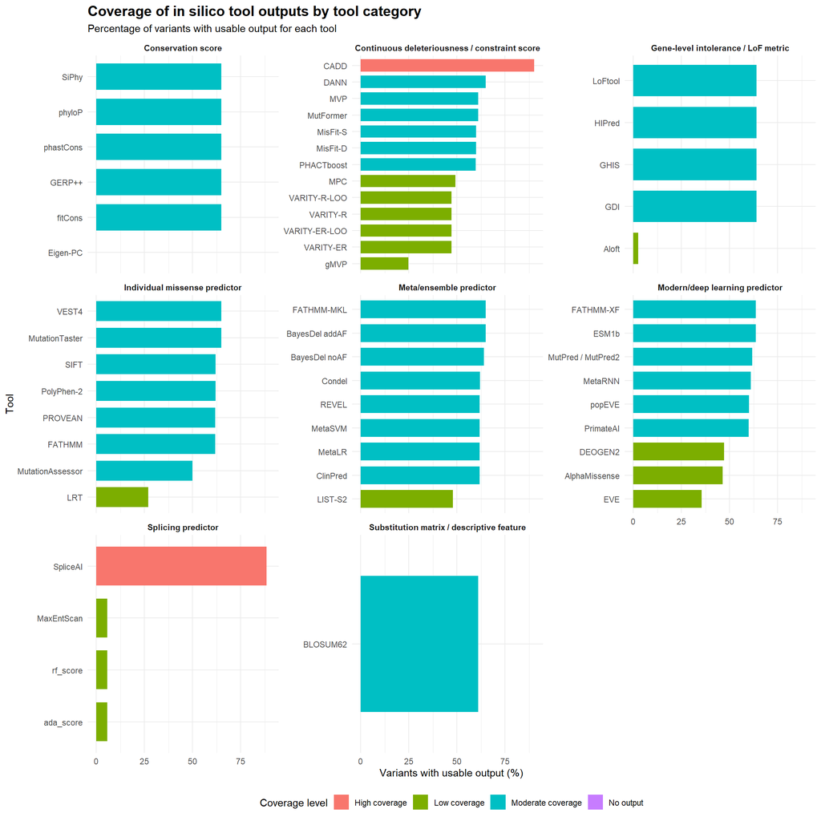

```r
tool_coverage_by_category_plot <- tool_coverage_by_category %>%
  mutate(
    coverage_group = case_when(
      percent_with_tool_output >= 80 ~ "High coverage",
      percent_with_tool_output >= 50 ~ "Moderate coverage",
      percent_with_tool_output > 0 ~ "Low coverage",
      TRUE ~ "No output"
    )
  ) %>%
  ggplot(
    aes(
      x = reorder(tool, percent_with_tool_output),
      y = percent_with_tool_output,
      fill = coverage_group
    )
  ) +
  geom_col(width = 0.75) +
  coord_flip() +
  facet_wrap(
    ~ tool_category,
    scales = "free_y"
  ) +
  labs(
    title = "Coverage of in silico tool outputs by tool category",
    subtitle = "Percentage of variants with usable output for each tool",
    x = "Tool",
    y = "Variants with usable output (%)",
    fill = "Coverage level"
  ) +
  theme_minimal(base_size = 11) +
  theme(
    plot.title = element_text(face = "bold", size = 15),
    plot.subtitle = element_text(size = 11),
    strip.text = element_text(face = "bold"),
    legend.position = "bottom"
  )

tool_coverage_by_category_plot
```

##save category plots

```r
# output_directory is already defined near the top of the notebook

if (!dir.exists(output_directory)) {
  dir.create(output_directory, recursive = TRUE)
}

readr::write_csv(
  tool_coverage_by_category,
  file.path(output_directory, "tool_coverage_by_category.csv")
)

readr::write_csv(
  category_coverage_summary,
  file.path(output_directory, "category_coverage_summary.csv")
)

readr::write_csv(
  individual_missense_coverage,
  file.path(output_directory, "individual_missense_coverage.csv")
)

readr::write_csv(
  meta_ensemble_coverage,
  file.path(output_directory, "meta_ensemble_coverage.csv")
)

readr::write_csv(
  modern_deep_learning_coverage,
  file.path(output_directory, "modern_deep_learning_coverage.csv")
)

readr::write_csv(
  splicing_coverage,
  file.path(output_directory, "splicing_coverage.csv")
)

readr::write_csv(
  continuous_score_coverage,
  file.path(output_directory, "continuous_score_coverage.csv")
)

readr::write_csv(
  conservation_coverage,
  file.path(output_directory, "conservation_coverage.csv")
)

readr::write_csv(
  gene_level_lof_coverage,
  file.path(output_directory, "gene_level_lof_coverage.csv")
)

readr::write_csv(
  descriptive_feature_coverage,
  file.path(output_directory, "descriptive_feature_coverage.csv")
)

ggsave(
  filename = file.path(output_directory, "tool_coverage_by_category_plot.png"),
  plot = tool_coverage_by_category_plot,
  width = 12,
  height = 12,
  dpi = 300)
```

###determine the number of tools included

```r
nrow(tool_coverage_results_table)
```

```
## [1] 55
```

# number of tools with no available outputs

```r
tools_with_no_output <- tool_coverage_summary %>%
  filter(variants_with_tool_output == 0) %>%
  select(
    tool,
    missing_columns
  )

tools_with_no_output
```

```
## # A tibble: 1 × 2
##   tool     missing_columns
##   <chr>    <chr>
## 1 Eigen-PC Eigen_PC_phred;Eigen_PC_raw;Eigen_PC_phred_new;Eigen_PC_raw_new
```

## save table

```r
# output_directory is already defined near the top of the notebook

if (!dir.exists(output_directory)) {
  dir.create(output_directory, recursive = TRUE)
}

readr::write_csv(
  tool_coverage_summary,
  file.path(output_directory, "tool_coverage_summary_full.csv")
)

readr::write_csv(
  tool_coverage_results_table,
  file.path(output_directory, "tool_coverage_results_table.csv")
)

readr::write_csv(
  tools_with_no_output,
  file.path(output_directory, "tools_with_no_output.csv"))
```

## plot of number of variants predicted by each tool

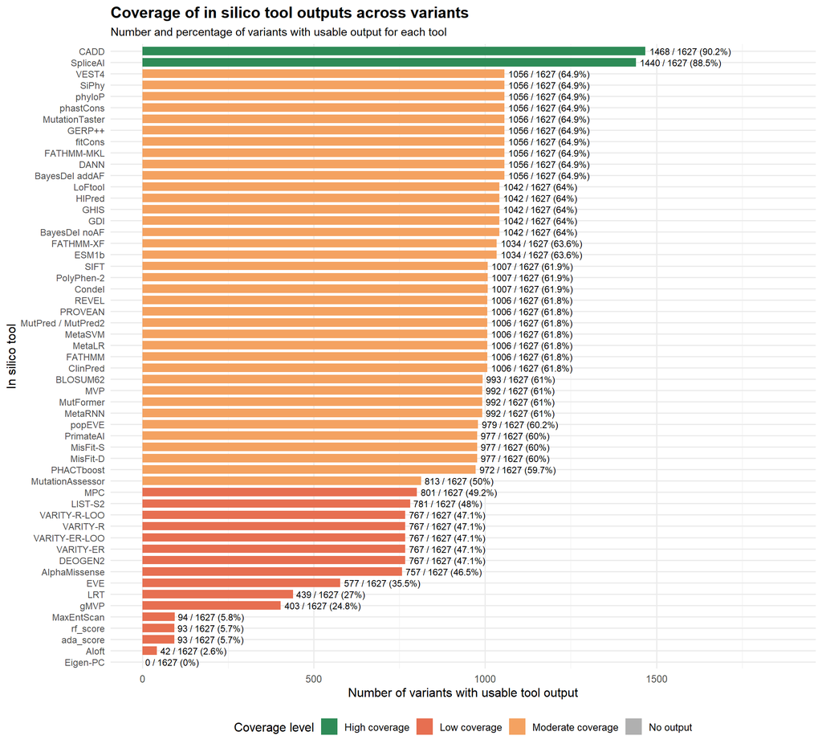

```r
tool_coverage_plot <- tool_coverage_results_table %>%
  mutate(
    coverage_group = case_when(
      percent_with_tool_output >= 80 ~ "High coverage",
      percent_with_tool_output >= 50 ~ "Moderate coverage",
      percent_with_tool_output > 0 ~ "Low coverage",
      TRUE ~ "No output"
    )
  ) %>%
  ggplot(
    aes(
      x = reorder(tool, variants_with_tool_output),
      y = variants_with_tool_output,
      fill = coverage_group
    )
  ) +
  geom_col(width = 0.75) +
  coord_flip() +
  geom_text(
    aes(
      label = paste0(
        variants_with_tool_output,
        " / ",
        total_variants,
        " (",
        percent_with_tool_output,
        "%)"
      )
    ),
    hjust = -0.05,
    size = 3
  ) +
  scale_fill_manual(
    values = c(
      "High coverage" = "#2E8B57",
      "Moderate coverage" = "#F4A261",
      "Low coverage" = "#E76F51",
      "No output" = "#B0B0B0"
    )
  ) +
  labs(
    title = "Coverage of in silico tool outputs across variants",
    subtitle = "Number and percentage of variants with usable output for each tool",
    x = "In silico tool",
    y = "Number of variants with usable tool output",
    fill = "Coverage level"
  ) +
  expand_limits(
    y = max(tool_coverage_results_table$total_variants) * 1.15
  ) +
  theme_minimal(base_size = 12) +
  theme(
    plot.title = element_text(face = "bold", size = 15),
    plot.subtitle = element_text(size = 11),
    axis.text.y = element_text(size = 9),
    legend.position = "bottom"
  )

tool_coverage_plot
```

```r
ggsave(
  filename = file.path(output_directory, "tool_coverage_plot.png"),
  plot = tool_coverage_plot,
  width = 11,
  height = 10,
  dpi = 300)
```

## Classification of tools for downstream analysis

the aim of this is to divide tools into various categories

```r
tool_analysis_group_map <- tibble::tribble(
  ~tool, ~analysis_group, ~reason,

  "SIFT", "Binary performance analysis", "Has established tolerated/deleterious threshold",
  "PolyPhen-2", "Binary performance analysis", "Has benign/possibly damaging/probably damaging interpretation",
  "MutationTaster", "Binary performance analysis", "Has categorical prediction labels",
  "LRT", "Binary performance analysis", "Has deleterious/neutral prediction interpretation",
  "MutationAssessor", "Binary performance analysis", "Has functional impact categories or score thresholds",
  "PROVEAN", "Binary performance analysis", "Has established deleterious/neutral threshold",
  "FATHMM", "Binary performance analysis", "Has established damaging/tolerated threshold",
  "FATHMM-MKL", "Binary performance analysis", "Has deleterious/neutral threshold",
  "VEST4", "Continuous score analysis", "No universal benign/pathogenic cutoff used here",

  "REVEL", "Binary performance analysis", "Commonly used threshold available",
  "ClinPred", "Binary performance analysis", "Has pathogenic/benign threshold",
  "MetaSVM", "Binary performance analysis", "Has tolerated/damaging threshold",
  "MetaLR", "Binary performance analysis", "Has tolerated/damaging threshold",
  "BayesDel addAF", "Binary performance analysis", "Has published threshold",
  "BayesDel noAF", "Binary performance analysis", "Has published threshold",
  "LIST-S2", "Binary performance analysis", "Has tolerated/deleterious threshold",
  "Condel", "Binary performance analysis", "Can use prediction label if available",

  "AlphaMissense", "Binary performance analysis", "Has likely benign, ambiguous and likely pathogenic classes",
  "EVE", "Binary performance analysis", "Can use EVE class labels",
  "popEVE", "Binary performance analysis", "Can use prediction labels if available",
  "ESM1b", "Continuous score analysis", "Threshold/direction depends on annotation source; use cautiously",
  "DEOGEN2", "Binary performance analysis", "Has prediction label or threshold",
  "MetaRNN", "Binary performance analysis", "Has prediction label",
  "MutPred / MutPred2", "Binary performance analysis", "Has score/prediction label; mainly missense-focused",
  "PrimateAI", "Binary performance analysis", "Has prediction label or threshold",
  "FATHMM-XF", "Binary performance analysis", "Has prediction label",

  "SpliceAI", "Splicing-specific analysis", "Predicts splice-altering potential",
  "ada_score", "Splicing-specific analysis", "Splicing predictor",
  "rf_score", "Splicing-specific analysis", "Splicing predictor",
  "MaxEntScan", "Splicing-specific analysis", "Splice-site strength/change score",

  "CADD", "Continuous score analysis", "Prioritisation/deleteriousness score; no universal diagnostic cutoff",
  "DANN", "Continuous score analysis", "Continuous deleteriousness score without universal clinical cutoff",
  "MPC", "Continuous score analysis", "Missense constraint score, not direct binary classifier",
  "MVP", "Continuous score analysis", "Continuous score; no universal binary threshold used here",
  "MutFormer", "Continuous score analysis", "Continuous score; no universal threshold used here",
  "PHACTboost", "Continuous score analysis", "Continuous score; no universal threshold used here",
  "VARITY-R", "Continuous score analysis", "Continuous score; no universal threshold used here",
  "VARITY-ER", "Continuous score analysis", "Continuous score; no universal threshold used here",
  "VARITY-R-LOO", "Continuous score analysis", "Continuous score; no universal threshold used here",
  "VARITY-ER-LOO", "Continuous score analysis", "Continuous score; no universal threshold used here",
  "gMVP", "Continuous score analysis", "Continuous score; no universal threshold used here",
  "MisFit-D", "Continuous score analysis", "Fitness/constraint-style score",
  "MisFit-S", "Continuous score analysis", "Fitness/constraint-style score",

  "GERP++", "Conservation/supporting analysis", "Evolutionary conservation score",
  "phyloP", "Conservation/supporting analysis", "Evolutionary conservation score",
  "phastCons", "Conservation/supporting analysis", "Evolutionary conservation score",
  "SiPhy", "Conservation/supporting analysis", "Evolutionary conservation score",
  "fitCons", "Conservation/supporting analysis", "Functional constraint score",
  "Eigen-PC", "Conservation/supporting analysis", "Functional/conservation-based supporting score",

  "Aloft", "Gene-level/LoF supporting analysis", "Loss-of-function/disease mechanism support",
  "LoFtool", "Gene-level/LoF supporting analysis", "Gene-level LoF intolerance score",
  "HIPred", "Gene-level/LoF supporting analysis", "Gene-level haploinsufficiency prediction",
  "GDI", "Gene-level/LoF supporting analysis", "Gene-level damage/intolerance score",
  "GHIS", "Gene-level/LoF supporting analysis", "Gene-level haploinsufficiency/intolerance score",

  "BLOSUM62", "Descriptive only", "Amino-acid substitution matrix, not a pathogenicity predictor"
)

tool_analysis_group_map
```

```
## # A tibble: 55 × 3
##    tool             analysis_group              reason
##    <chr>            <chr>                       <chr>
##  1 SIFT             Binary performance analysis Has established tolerated/delet…
##  2 PolyPhen-2       Binary performance analysis Has benign/possibly damaging/pr…
##  3 MutationTaster   Binary performance analysis Has categorical prediction labe…
##  4 LRT              Binary performance analysis Has deleterious/neutral predict…
##  5 MutationAssessor Binary performance analysis Has functional impact categorie…
##  6 PROVEAN          Binary performance analysis Has established deleterious/neu…
##  7 FATHMM           Binary performance analysis Has established damaging/tolera…
##  8 FATHMM-MKL       Binary performance analysis Has deleterious/neutral thresho…
##  9 VEST4            Continuous score analysis   No universal benign/pathogenic …
## 10 REVEL            Binary performance analysis Commonly used threshold availab…
## # ℹ 45 more rows
```

## add to coverage table

```r
tool_coverage_analysis_groups <- tool_coverage_by_category %>%
  left_join(
    tool_analysis_group_map,
    by = "tool"
  ) %>%
  mutate(
    analysis_group = ifelse(
      is.na(analysis_group),
      "Unassigned",
      analysis_group
    ),
    reason = ifelse(
      is.na(reason),
      "No downstream analysis group assigned",
      reason
    )
  ) %>%
  arrange(
    analysis_group,
    desc(percent_with_tool_output)
  )

tool_coverage_analysis_groups
```

```
## # A tibble: 55 × 8
##    tool_category                  tool     total_variants variants_with_tool_o…¹
##    <chr>                          <chr>             <int>                  <dbl>
##  1 Individual missense predictor  Mutatio…           1627                   1056
##  2 Meta/ensemble predictor        FATHMM-…           1627                   1056
##  3 Meta/ensemble predictor        BayesDe…           1627                   1056
##  4 Meta/ensemble predictor        BayesDe…           1627                   1042
##  5 Modern/deep learning predictor FATHMM-…           1627                   1034
##  6 Individual missense predictor  SIFT               1627                   1007
##  7 Individual missense predictor  PolyPhe…           1627                   1007
##  8 Meta/ensemble predictor        Condel             1627                   1007
##  9 Individual missense predictor  PROVEAN            1627                   1006
## 10 Individual missense predictor  FATHMM             1627                   1006
## # ℹ 45 more rows
## # ℹ abbreviated name: ¹variants_with_tool_output
## # ℹ 4 more variables: variants_without_tool_output <int>,
## #   percent_with_tool_output <dbl>, analysis_group <chr>, reason <chr>
```

## summarise tools accprding to analysis group

```r
analysis_group_summary <- tool_coverage_analysis_groups %>%
  group_by(analysis_group) %>%
  summarise(
    number_of_tools = n(),
    mean_coverage_percent = round(mean(percent_with_tool_output, na.rm = TRUE), 1),
    median_coverage_percent = round(median(percent_with_tool_output, na.rm = TRUE), 1),
    highest_coverage_percent = max(percent_with_tool_output, na.rm = TRUE),
    lowest_coverage_percent = min(percent_with_tool_output, na.rm = TRUE),
    .groups = "drop"
  ) %>%
  arrange(desc(mean_coverage_percent))

analysis_group_summary
```

```
## # A tibble: 6 × 6
##   analysis_group    number_of_tools mean_coverage_percent median_coverage_perc…¹
##   <chr>                       <int>                 <dbl>                  <dbl>
## 1 Descriptive only                1                  61                     61
## 2 Binary performan…              24                  57.3                   61.8
## 3 Continuous score…              15                  56.5                   60
## 4 Conservation/sup…               6                  54.1                   64.9
## 5 Gene-level/LoF s…               5                  51.7                   64
## 6 Splicing-specifi…               4                  26.4                    5.8
## # ℹ abbreviated name: ¹median_coverage_percent
## # ℹ 2 more variables: highest_coverage_percent <dbl>,
## #   lowest_coverage_percent <dbl>
```

# creating binary analysis table

```r
binary_analysis_candidate_tools <- tool_coverage_analysis_groups %>%
  filter(analysis_group == "Binary performance analysis") %>%
  arrange(desc(percent_with_tool_output))

binary_analysis_candidate_tools
```

```
## # A tibble: 24 × 8
##    tool_category                  tool     total_variants variants_with_tool_o…¹
##    <chr>                          <chr>             <int>                  <dbl>
##  1 Individual missense predictor  Mutatio…           1627                   1056
##  2 Meta/ensemble predictor        FATHMM-…           1627                   1056
##  3 Meta/ensemble predictor        BayesDe…           1627                   1056
##  4 Meta/ensemble predictor        BayesDe…           1627                   1042
##  5 Modern/deep learning predictor FATHMM-…           1627                   1034
##  6 Individual missense predictor  SIFT               1627                   1007
##  7 Individual missense predictor  PolyPhe…           1627                   1007
##  8 Meta/ensemble predictor        Condel             1627                   1007
##  9 Individual missense predictor  PROVEAN            1627                   1006
## 10 Individual missense predictor  FATHMM             1627                   1006
## # ℹ 14 more rows
## # ℹ abbreviated name: ¹variants_with_tool_output
## # ℹ 4 more variables: variants_without_tool_output <int>,
## #   percent_with_tool_output <dbl>, analysis_group <chr>, reason <chr>
```